# ADVANCED PYTHON WITH DATA SCIENCE

DATA SCIENCE:

DATA ANALYTICS:

Data analytics (DA) is the process of examining data sets in order to draw conclusions about the information they contain, increasingly with the aid of specialized systems and software. Data is extracted and categorized to identify, analyze behavioral data and patterns.

DATASETS:

A data set is a collection of data. In the case of tabular data, a data set corresponds to one or more database tables, where every column of a table represents a particular variable, and each row corresponds to a given record of the data set

# READING A CSV FILE

```python
# Importing Required Packages for DATA VISUALISATION
import pandas as pd
import numpy as np
import seaborn as sb
import matplotlib.pyplot as pyp
from sklearn import preprocessing
```

## Pandas

Pandas is a Python library providing high-performance, easy-to-use data structures and data analysis tools. Python with Pandas is used in a wide range of fields including academic and commercial domains including finance, economics, Statistics, analytics, etc. The two primary data structures of pandas, Series (1-dimensional) and DataFrame (2-dimensional), handle the vast majority of typical use cases in finance, statistics, social science, and many areas of engineering. pandas is well suited for many different kinds of data:

- Tabular data with heterogeneously-typed columns, as in an SQL table or Excel spread sheet
- Ordered and unordered (not necessarily fixed-frequency) time series data.
- Arbitrary matrix data (homogeneously typed or heterogeneous) with row and column labels
- Any other form of observational / statistical data sets. The data actually need not be labelled at all to be placed into a pandas data structure

## Reading A DataSet

```python
#Reading a csv file
mob_data = pd.read_csv("Mobile_Data.csv")
```

```python
#Visualising our data
mob_data.head(5)
```

|  | PhoneId | Pixel Density | Screen Size | Weight | RAM | Processor_frequency | Screen to Body Ratio (calculated) | Height | Internal Memory | Capacity | Resolution | Rating | Brand | OS Name | Sim 1 | Sim 2 | SIM Slot | Processesor |
| --- | --- | --- | --- | --- | --- | --- | --- | --- | --- | --- | --- | --- | --- | --- | --- | --- | --- | --- |
| 0 | 0 | 403 | 6.26 | 182 | 4 | 1.8 | 80.68 | 157.9 | 64 | 4000 | 20 | 4.5 | Xiaomi | Android | 4G | 4G | Dual SIM, GSM+GSM, Dual VoLTE | Octa |
| 1 | 1 | 271 | 6.20 | 168 | 3 | 1.8 | 80.85 | 156.2 | 32 | 4230 | 8 | 4.5 | Realme | Android | 4G | 4G | Dual SIM, GSM+GSM, Dual VoLTE | Octa |
| 2 | 2 | 409 | 6.30 | 168 | 3 | 2.1 | 83.68 | 157.0 | 32 | 3500 | 25 | 4.4 | Realme | Android | 4G | 4G | Dual SIM, GSM+GSM, Dual VoLTE | Octa |
| 3 | 4 | 411 | 6.00 | 169 | 4 | 2.2 | 74.78 | 159.8 | 64 | 3300 | 24 | 4.3 | Samsung | Android | 4G | 4G | Dual SIM, GSM+GSM | Octa |
| 4 | 5 | 396 | 6.50 | 175 | 4 | 2.2 | 84.23 | 160.4 | 64 | 3750 | 16 | 4.4 | Honor | Android | 4G | 4G | Dual SIM, GSM+GSM, Dual VoLTE | Octa |

```python
#"ONE HOT ENCODING" for Brand Names
mob_data_brand_names_encoded = pd.get_dummies(mob_data,prefix=["Brand"],columns = ["Brand"])
```

## One Hot Encoding of datasets in Python

Sometimes in datasets, we encounter columns that contain numbers / labels of no specific order of preference. The data in the column usually denotes a category or value of the category. This confuses the machine learning model, to avoid this, the data in the column should be One Hot encoded.

#### One Hot Encoding

It refers to splitting the column which contains categorical data to many columns depending on the number of categories present in that column. Each column contains “0” or “1” corresponding to which column it has been placed.

```python
mob_data_brand_names_encoded.head()
```

|  | PhoneId | Pixel Density | Screen Size | Weight | RAM | Processor_frequency | Screen to Body Ratio (calculated) | Height | Internal Memory | Capacity | ... | Brand_Samsung | Brand_Sony | Brand_Tecno | Brand_Ulefone | Brand_VOTO | Brand_Vivo | Brand_Xiaomi | Brand_Xiaomi Poco | Brand_Yu | Brand_iVooMi |
| --- | --- | --- | --- | --- | --- | --- | --- | --- | --- | --- | --- | --- | --- | --- | --- | --- | --- | --- | --- | --- | --- |
| 0 | 0 | 403 | 6.26 | 182 | 4 | 1.8 | 80.68 | 157.9 | 64 | 4000 | ... | 0 | 0 | 0 | 0 | 0 | 0 | 1 | 0 | 0 | 0 |
| 1 | 1 | 271 | 6.20 | 168 | 3 | 1.8 | 80.85 | 156.2 | 32 | 4230 | ... | 0 | 0 | 0 | 0 | 0 | 0 | 0 | 0 | 0 | 0 |
| 2 | 2 | 409 | 6.30 | 168 | 3 | 2.1 | 83.68 | 157.0 | 32 | 3500 | ... | 0 | 0 | 0 | 0 | 0 | 0 | 0 | 0 | 0 | 0 |
| 3 | 4 | 411 | 6.00 | 169 | 4 | 2.2 | 74.78 | 159.8 | 64 | 3300 | ... | 1 | 0 | 0 | 0 | 0 | 0 | 0 | 0 | 0 | 0 |
| 4 | 5 | 396 | 6.50 | 175 | 4 | 2.2 | 84.23 | 160.4 | 64 | 3750 | ... | 0 | 0 | 0 | 0 | 0 | 0 | 0 | 0 | 0 | 0 |

5 rows × 64 columns

```python
#"ONE HOT ENCODING" for OS Names
mob_data_os_names_encoded = pd.get_dummies(mob_data_brand_names_encoded,prefix=["OS"],columns = ["OS Name"])
```

```python
mob_data_os_names_encoded.head()
```

|  | PhoneId | Pixel Density | Screen Size | Weight | RAM | Processor_frequency | Screen to Body Ratio (calculated) | Height | Internal Memory | Capacity | ... | Brand_Xiaomi Poco | Brand_Yu | Brand_iVooMi | OS_Android | OS_Blackberry | OS_KAI | OS_Nokia | OS_Other | OS_Tizen | OS_iOS |
| --- | --- | --- | --- | --- | --- | --- | --- | --- | --- | --- | --- | --- | --- | --- | --- | --- | --- | --- | --- | --- | --- |
| 0 | 0 | 403 | 6.26 | 182 | 4 | 1.8 | 80.68 | 157.9 | 64 | 4000 | ... | 0 | 0 | 0 | 1 | 0 | 0 | 0 | 0 | 0 | 0 |
| 1 | 1 | 271 | 6.20 | 168 | 3 | 1.8 | 80.85 | 156.2 | 32 | 4230 | ... | 0 | 0 | 0 | 1 | 0 | 0 | 0 | 0 | 0 | 0 |
| 2 | 2 | 409 | 6.30 | 168 | 3 | 2.1 | 83.68 | 157.0 | 32 | 3500 | ... | 0 | 0 | 0 | 1 | 0 | 0 | 0 | 0 | 0 | 0 |
| 3 | 4 | 411 | 6.00 | 169 | 4 | 2.2 | 74.78 | 159.8 | 64 | 3300 | ... | 0 | 0 | 0 | 1 | 0 | 0 | 0 | 0 | 0 | 0 |
| 4 | 5 | 396 | 6.50 | 175 | 4 | 2.2 | 84.23 | 160.4 | 64 | 3750 | ... | 0 | 0 | 0 | 1 | 0 | 0 | 0 | 0 | 0 | 0 |

5 rows × 70 columns

```python
#"ONE HOT ENCODING" for SIM1 and SIM2
mob_data_sim1_encoded = pd.get_dummies(mob_data_os_names_encoded,prefix=["SIM1"],columns = ["Sim 1"])
mob_data_sim2_encoded = pd.get_dummies(mob_data_sim1_encoded,prefix=["SIM2"],columns = ["Sim 2"])
```

```python
mob_data_sim2_encoded.head()
```

|  | PhoneId | Pixel Density | Screen Size | Weight | RAM | Processor_frequency | Screen to Body Ratio (calculated) | Height | Internal Memory | Capacity | ... | OS_Other | OS_Tizen | OS_iOS | SIM1_2G | SIM1_3G | SIM1_4G | SIM2_2G | SIM2_3G | SIM2_4G | SIM2_Other |
| --- | --- | --- | --- | --- | --- | --- | --- | --- | --- | --- | --- | --- | --- | --- | --- | --- | --- | --- | --- | --- | --- |
| 0 | 0 | 403 | 6.26 | 182 | 4 | 1.8 | 80.68 | 157.9 | 64 | 4000 | ... | 0 | 0 | 0 | 0 | 0 | 1 | 0 | 0 | 1 | 0 |
| 1 | 1 | 271 | 6.20 | 168 | 3 | 1.8 | 80.85 | 156.2 | 32 | 4230 | ... | 0 | 0 | 0 | 0 | 0 | 1 | 0 | 0 | 1 | 0 |
| 2 | 2 | 409 | 6.30 | 168 | 3 | 2.1 | 83.68 | 157.0 | 32 | 3500 | ... | 0 | 0 | 0 | 0 | 0 | 1 | 0 | 0 | 1 | 0 |
| 3 | 4 | 411 | 6.00 | 169 | 4 | 2.2 | 74.78 | 159.8 | 64 | 3300 | ... | 0 | 0 | 0 | 0 | 0 | 1 | 0 | 0 | 1 | 0 |
| 4 | 5 | 396 | 6.50 | 175 | 4 | 2.2 | 84.23 | 160.4 | 64 | 3750 | ... | 0 | 0 | 0 | 0 | 0 | 1 | 0 | 0 | 1 | 0 |

5 rows × 75 columns

```python
#"ONE HOT ENCODING" for SIM slot types and Processor
mob_data_simslot_encoded = pd.get_dummies(mob_data_sim2_encoded,prefix=["SimSlots"],columns = ["SIM Slot"])
mob_data_processor_encoded = pd.get_dummies(mob_data_simslot_encoded,prefix=["Num_Cores"],columns = ["Processesor"])
```

```python
#copying my dataframe to another datframe
mob_data_encoded = mob_data_processor_encoded
```

```python
mob_data_encoded.head()
```

|  | PhoneId | Pixel Density | Screen Size | Weight | RAM | Processor_frequency | Screen to Body Ratio (calculated) | Height | Internal Memory | Capacity | ... | SimSlots_Dual SIM, GSM+GSM, Dual VoLTE | SimSlots_Single SIM, GSM | Num_Cores_312 | Num_Cores_Deca | Num_Cores_Dual | Num_Cores_Hexa | Num_Cores_Octa | Num_Cores_Other | Num_Cores_Quad | Num_Cores_Tru-Octa |
| --- | --- | --- | --- | --- | --- | --- | --- | --- | --- | --- | --- | --- | --- | --- | --- | --- | --- | --- | --- | --- | --- |
| 0 | 0 | 403 | 6.26 | 182 | 4 | 1.8 | 80.68 | 157.9 | 64 | 4000 | ... | 1 | 0 | 0 | 0 | 0 | 0 | 1 | 0 | 0 | 0 |
| 1 | 1 | 271 | 6.20 | 168 | 3 | 1.8 | 80.85 | 156.2 | 32 | 4230 | ... | 1 | 0 | 0 | 0 | 0 | 0 | 1 | 0 | 0 | 0 |
| 2 | 2 | 409 | 6.30 | 168 | 3 | 2.1 | 83.68 | 157.0 | 32 | 3500 | ... | 1 | 0 | 0 | 0 | 0 | 0 | 1 | 0 | 0 | 0 |
| 3 | 4 | 411 | 6.00 | 169 | 4 | 2.2 | 74.78 | 159.8 | 64 | 3300 | ... | 0 | 0 | 0 | 0 | 0 | 0 | 1 | 0 | 0 | 0 |
| 4 | 5 | 396 | 6.50 | 175 | 4 | 2.2 | 84.23 | 160.4 | 64 | 3750 | ... | 1 | 0 | 0 | 0 | 0 | 0 | 1 | 0 | 0 | 0 |

5 rows × 85 columns

```python
#visualising shape of my final dataframe
mob_data_encoded.shape
```

```
(341, 85)
```

```python
#slicing my dataframe to a new dataframe
mob_data_sliced = mob_data_encoded[0:10]
```

```python
#visualising new dataframe
mob_data_sliced.head()
```

|  | PhoneId | Pixel Density | Screen Size | Weight | RAM | Processor_frequency | Screen to Body Ratio (calculated) | Height | Internal Memory | Capacity | ... | SimSlots_Dual SIM, GSM+GSM, Dual VoLTE | SimSlots_Single SIM, GSM | Num_Cores_312 | Num_Cores_Deca | Num_Cores_Dual | Num_Cores_Hexa | Num_Cores_Octa | Num_Cores_Other | Num_Cores_Quad | Num_Cores_Tru-Octa |
| --- | --- | --- | --- | --- | --- | --- | --- | --- | --- | --- | --- | --- | --- | --- | --- | --- | --- | --- | --- | --- | --- |
| 0 | 0 | 403 | 6.26 | 182 | 4 | 1.8 | 80.68 | 157.9 | 64 | 4000 | ... | 1 | 0 | 0 | 0 | 0 | 0 | 1 | 0 | 0 | 0 |
| 1 | 1 | 271 | 6.20 | 168 | 3 | 1.8 | 80.85 | 156.2 | 32 | 4230 | ... | 1 | 0 | 0 | 0 | 0 | 0 | 1 | 0 | 0 | 0 |
| 2 | 2 | 409 | 6.30 | 168 | 3 | 2.1 | 83.68 | 157.0 | 32 | 3500 | ... | 1 | 0 | 0 | 0 | 0 | 0 | 1 | 0 | 0 | 0 |
| 3 | 4 | 411 | 6.00 | 169 | 4 | 2.2 | 74.78 | 159.8 | 64 | 3300 | ... | 0 | 0 | 0 | 0 | 0 | 0 | 1 | 0 | 0 | 0 |
| 4 | 5 | 396 | 6.50 | 175 | 4 | 2.2 | 84.23 | 160.4 | 64 | 3750 | ... | 1 | 0 | 0 | 0 | 0 | 0 | 1 | 0 | 0 | 0 |

5 rows × 85 columns

```python
#here Shape reduces as we sliced them
mob_data_sliced.shape
```

```
(10, 85)
```

```python
#accessing a specified columns and rows in dataframe
print(mob_data_encoded["Internal Memory"][0:5])
```

```
0    64
1    32
2    32
3    64
4    64
Name: Internal Memory, dtype: int64
```

```python
#sorting Dataframe with respect to Screen Size
mob_data_encoded.sort_values("Screen Size", ascending=True)
```

|  | PhoneId | Pixel Density | Screen Size | Weight | RAM | Processor_frequency | Screen to Body Ratio (calculated) | Height | Internal Memory | Capacity | ... | SimSlots_Dual SIM, GSM+GSM, Dual VoLTE | SimSlots_Single SIM, GSM | Num_Cores_312 | Num_Cores_Deca | Num_Cores_Dual | Num_Cores_Hexa | Num_Cores_Octa | Num_Cores_Other | Num_Cores_Quad | Num_Cores_Tru-Octa |
| --- | --- | --- | --- | --- | --- | --- | --- | --- | --- | --- | --- | --- | --- | --- | --- | --- | --- | --- | --- | --- | --- |
| 46 | 63 | 167 | 2.40 | 161 | 512 | 1.00 | 72.35 | 149.946394 | 4 | 2000 | ... | 0 | 1 | 0 | 0 | 1 | 0 | 0 | 0 | 0 | 0 |
| 113 | 149 | 167 | 2.40 | 161 | 16 | 1.79 | 30.11 | 118.000000 | 32 | 1020 | ... | 0 | 0 | 0 | 0 | 0 | 0 | 0 | 1 | 0 | 0 |
| 294 | 409 | 167 | 2.40 | 161 | 8 | 1.79 | 30.49 | 116.400000 | 32 | 1100 | ... | 0 | 0 | 0 | 0 | 0 | 0 | 0 | 1 | 0 | 0 |
| 131 | 178 | 167 | 2.40 | 81 | 3 | 1.79 | 30.11 | 118.000000 | 32 | 1020 | ... | 0 | 0 | 0 | 0 | 0 | 0 | 0 | 1 | 0 | 0 |
| 183 | 247 | 167 | 2.40 | 91 | 32 | 1.79 | 29.59 | 117.500000 | 32 | 1200 | ... | 0 | 0 | 0 | 0 | 0 | 0 | 0 | 1 | 0 | 0 |
| 126 | 168 | 167 | 2.40 | 161 | 3 | 1.79 | 30.26 | 115.600000 | 0 | 1200 | ... | 0 | 0 | 0 | 0 | 0 | 0 | 0 | 1 | 0 | 0 |
| 74 | 97 | 167 | 2.40 | 58 | 512 | 1.10 | 23.60 | 134.000000 | 4 | 2000 | ... | 0 | 0 | 0 | 0 | 1 | 0 | 0 | 0 | 0 | 0 |
| 57 | 75 | 163 | 2.45 | 117 | 512 | 1.10 | 28.26 | 133.400000 | 4 | 1500 | ... | 0 | 0 | 0 | 0 | 1 | 0 | 0 | 0 | 0 | 0 |
| 171 | 232 | 143 | 2.80 | 161 | 8 | 1.79 | 35.30 | 124.000000 | 32 | 1200 | ... | 0 | 0 | 0 | 0 | 0 | 0 | 0 | 1 | 0 | 0 |
| 136 | 185 | 143 | 2.80 | 105 | 64 | 1.79 | 33.30 | 126.800000 | 32 | 1200 | ... | 0 | 0 | 1 | 0 | 0 | 0 | 0 | 0 | 0 | 0 |
| 81 | 106 | 326 | 4.00 | 113 | 2 | 1.84 | 60.66 | 123.800000 | 32 | 1642 | ... | 0 | 1 | 0 | 0 | 1 | 0 | 0 | 0 | 0 | 0 |
| 297 | 412 | 233 | 4.00 | 120 | 512 | 1.30 | 57.46 | 125.000000 | 4 | 1300 | ... | 0 | 0 | 0 | 0 | 0 | 0 | 0 | 0 | 1 | 0 |
| 209 | 287 | 233 | 4.00 | 161 | 1 | 1.30 | 59.67 | 120.000000 | 8 | 1600 | ... | 0 | 0 | 0 | 0 | 0 | 0 | 0 | 0 | 1 | 0 |
| 252 | 349 | 233 | 4.00 | 100 | 1 | 1.30 | 60.68 | 118.000000 | 8 | 2300 | ... | 0 | 0 | 0 | 0 | 0 | 0 | 0 | 0 | 1 | 0 |
| 305 | 422 | 233 | 4.00 | 132 | 1 | 1.30 | 57.15 | 124.500000 | 8 | 2000 | ... | 0 | 0 | 0 | 0 | 0 | 0 | 0 | 0 | 1 | 0 |
| 184 | 248 | 233 | 4.00 | 124 | 512 | 1.30 | 59.24 | 123.000000 | 4 | 1700 | ... | 0 | 0 | 0 | 0 | 0 | 0 | 0 | 0 | 1 | 0 |
| 179 | 241 | 233 | 4.00 | 118 | 1 | 1.30 | 57.63 | 122.900000 | 8 | 1400 | ... | 0 | 0 | 0 | 0 | 0 | 0 | 0 | 0 | 1 | 0 |
| 291 | 405 | 355 | 4.20 | 136 | 2 | 1.50 | 58.88 | 130.000000 | 16 | 1800 | ... | 0 | 1 | 0 | 0 | 1 | 0 | 0 | 0 | 0 | 0 |
| 257 | 357 | 433 | 4.50 | 156 | 4 | 1.80 | 56.02 | 150.200000 | 64 | 3000 | ... | 0 | 0 | 0 | 0 | 0 | 0 | 1 | 0 | 0 | 0 |
| 285 | 397 | 218 | 4.50 | 145 | 1 | 1.20 | 64.18 | 130.700000 | 16 | 2000 | ... | 0 | 0 | 0 | 0 | 0 | 0 | 0 | 0 | 1 | 0 |
| 256 | 355 | 218 | 4.50 | 130 | 1 | 1.10 | 60.90 | 136.500000 | 8 | 2000 | ... | 0 | 0 | 0 | 0 | 0 | 0 | 0 | 0 | 1 | 0 |
| 197 | 271 | 218 | 4.50 | 140 | 1 | 1.10 | 61.95 | 135.000000 | 8 | 2000 | ... | 0 | 0 | 0 | 0 | 0 | 0 | 0 | 0 | 1 | 0 |
| 296 | 411 | 218 | 4.50 | 161 | 1 | 1.30 | 72.35 | 149.946394 | 8 | 1300 | ... | 0 | 0 | 0 | 0 | 0 | 0 | 0 | 0 | 1 | 0 |
| 282 | 393 | 207 | 4.50 | 143 | 1 | 1.50 | 62.67 | 132.900000 | 8 | 2050 | ... | 0 | 0 | 0 | 0 | 0 | 0 | 0 | 0 | 1 | 0 |
| 207 | 283 | 453 | 4.50 | 196 | 3 | 2.20 | 56.52 | 128.000000 | 32 | 3450 | ... | 0 | 1 | 0 | 0 | 0 | 0 | 0 | 0 | 1 | 0 |
| 92 | 122 | 218 | 4.50 | 131 | 1 | 1.10 | 61.58 | 133.600000 | 8 | 2150 | ... | 0 | 0 | 0 | 0 | 0 | 0 | 0 | 0 | 1 | 0 |
| 324 | 449 | 218 | 4.50 | 132 | 1 | 1.30 | 63.93 | 132.000000 | 8 | 1850 | ... | 0 | 0 | 0 | 0 | 0 | 0 | 0 | 0 | 1 | 0 |
| 339 | 470 | 218 | 4.50 | 156 | 1 | 1.30 | 63.93 | 132.000000 | 8 | 1800 | ... | 0 | 0 | 0 | 0 | 0 | 0 | 0 | 0 | 1 | 0 |
| 318 | 442 | 218 | 4.50 | 138 | 1 | 1.10 | 63.45 | 132.700000 | 8 | 2000 | ... | 0 | 0 | 0 | 0 | 0 | 0 | 0 | 0 | 1 | 0 |
| 213 | 292 | 326 | 4.70 | 129 | 1 | 1.40 | 65.66 | 138.100000 | 16 | 1810 | ... | 0 | 1 | 0 | 0 | 1 | 0 | 0 | 0 | 0 | 0 |
| ... | ... | ... | ... | ... | ... | ... | ... | ... | ... | ... | ... | ... | ... | ... | ... | ... | ... | ... | ... | ... | ... |
| 30 | 47 | 269 | 6.26 | 167 | 4 | 1.80 | 80.80 | 158.700000 | 32 | 4000 | ... | 1 | 0 | 0 | 0 | 0 | 0 | 1 | 0 | 0 | 0 |
| 28 | 44 | 403 | 6.26 | 175 | 4 | 1.95 | 81.64 | 157.900000 | 64 | 5000 | ... | 1 | 0 | 0 | 0 | 0 | 0 | 1 | 0 | 0 | 0 |
| 53 | 70 | 402 | 6.28 | 177 | 6 | 2.80 | 83.55 | 155.700000 | 64 | 3300 | ... | 1 | 0 | 0 | 0 | 0 | 0 | 1 | 0 | 0 | 0 |
| 116 | 156 | 402 | 6.28 | 161 | 6 | 2.20 | 84.93 | 154.400000 | 128 | 3200 | ... | 0 | 0 | 0 | 0 | 0 | 0 | 1 | 0 | 0 | 0 |
| 2 | 2 | 409 | 6.30 | 168 | 3 | 2.10 | 83.68 | 157.000000 | 32 | 3500 | ... | 1 | 0 | 0 | 0 | 0 | 0 | 1 | 0 | 0 | 0 |
| 198 | 273 | 400 | 6.30 | 150 | 4 | 1.95 | 84.91 | 154.800000 | 64 | 3260 | ... | 0 | 0 | 0 | 0 | 0 | 0 | 1 | 0 | 0 | 0 |
| 40 | 57 | 409 | 6.30 | 168 | 4 | 2.10 | 83.68 | 157.000000 | 64 | 3500 | ... | 1 | 0 | 0 | 0 | 0 | 0 | 1 | 0 | 0 | 0 |
| 144 | 194 | 392 | 6.30 | 183 | 8 | 2.20 | 80.86 | 162.500000 | 128 | 3800 | ... | 0 | 0 | 0 | 0 | 0 | 0 | 1 | 0 | 0 | 0 |
| 120 | 160 | 409 | 6.30 | 166 | 6 | 2.36 | 84.02 | 157.000000 | 128 | 3750 | ... | 1 | 0 | 0 | 0 | 0 | 0 | 1 | 0 | 0 | 0 |
| 38 | 55 | 409 | 6.30 | 169 | 4 | 2.20 | 82.03 | 157.600000 | 128 | 3340 | ... | 1 | 0 | 0 | 0 | 0 | 0 | 1 | 0 | 0 | 0 |
| 35 | 52 | 400 | 6.30 | 150 | 6 | 1.95 | 84.91 | 154.800000 | 64 | 3260 | ... | 0 | 0 | 0 | 0 | 0 | 0 | 1 | 0 | 0 | 0 |
| 13 | 18 | 400 | 6.30 | 150 | 4 | 2.20 | 84.87 | 154.810000 | 64 | 3260 | ... | 0 | 0 | 0 | 0 | 0 | 0 | 1 | 0 | 0 | 0 |
| 18 | 26 | 409 | 6.30 | 176 | 4 | 2.36 | 82.98 | 157.900000 | 64 | 3750 | ... | 1 | 0 | 0 | 0 | 0 | 0 | 1 | 0 | 0 | 0 |
| 26 | 38 | 392 | 6.30 | 183 | 6 | 2.20 | 80.86 | 162.500000 | 128 | 3800 | ... | 0 | 0 | 0 | 0 | 0 | 0 | 1 | 0 | 0 | 0 |
| 110 | 146 | 409 | 6.30 | 176 | 6 | 2.36 | 82.98 | 157.900000 | 64 | 3750 | ... | 1 | 0 | 0 | 0 | 0 | 0 | 1 | 0 | 0 | 0 |
| 94 | 124 | 409 | 6.30 | 169 | 6 | 2.00 | 83.84 | 156.700000 | 128 | 3500 | ... | 1 | 0 | 0 | 0 | 0 | 0 | 1 | 0 | 0 | 0 |
| 109 | 145 | 522 | 6.30 | 184 | 4 | 2.50 | 83.49 | 158.000000 | 64 | 3430 | ... | 0 | 1 | 0 | 0 | 0 | 0 | 1 | 0 | 0 | 0 |
| 29 | 45 | 538 | 6.39 | 189 | 6 | 2.60 | 87.66 | 157.800000 | 128 | 4200 | ... | 1 | 0 | 0 | 0 | 0 | 0 | 1 | 0 | 0 | 0 |
| 95 | 125 | 344 | 6.40 | 211 | 4 | 2.00 | 72.95 | 174.100000 | 64 | 5300 | ... | 0 | 0 | 0 | 0 | 0 | 0 | 1 | 0 | 0 | 0 |
| 58 | 76 | 403 | 6.40 | 182 | 8 | 2.00 | 85.05 | 157.500000 | 128 | 3500 | ... | 1 | 0 | 0 | 0 | 0 | 0 | 1 | 0 | 0 | 0 |
| 55 | 73 | 403 | 6.40 | 186 | 8 | 2.65 | 86.29 | 156.700000 | 256 | 3730 | ... | 0 | 0 | 0 | 0 | 0 | 0 | 1 | 0 | 0 | 0 |
| 10 | 14 | 402 | 6.41 | 185 | 6 | 2.80 | 85.43 | 157.500000 | 128 | 3700 | ... | 0 | 0 | 0 | 0 | 0 | 0 | 1 | 0 | 0 | 0 |
| 145 | 195 | 402 | 6.41 | 185 | 8 | 2.80 | 85.43 | 157.500000 | 128 | 3700 | ... | 0 | 0 | 0 | 0 | 0 | 0 | 1 | 0 | 0 | 0 |
| 5 | 7 | 402 | 6.41 | 156 | 6 | 2.20 | 84.98 | 157.900000 | 64 | 3400 | ... | 1 | 0 | 0 | 0 | 0 | 0 | 1 | 0 | 0 | 0 |
| 76 | 99 | 456 | 6.50 | 208 | 4 | 2.49 | 84.89 | 157.500000 | 64 | 3174 | ... | 0 | 0 | 0 | 0 | 0 | 1 | 0 | 0 | 0 | 0 |
| 4 | 5 | 396 | 6.50 | 175 | 4 | 2.20 | 84.23 | 160.400000 | 64 | 3750 | ... | 1 | 0 | 0 | 0 | 0 | 0 | 1 | 0 | 0 | 0 |
| 115 | 155 | 396 | 6.50 | 175 | 6 | 2.20 | 84.23 | 160.400000 | 64 | 3750 | ... | 1 | 0 | 0 | 0 | 0 | 0 | 1 | 0 | 0 | 0 |
| 261 | 363 | 456 | 6.50 | 208 | 4 | 2.49 | 84.89 | 157.500000 | 512 | 3174 | ... | 0 | 0 | 0 | 0 | 0 | 1 | 0 | 0 | 0 | 0 |
| 193 | 262 | 456 | 6.50 | 208 | 4 | 2.49 | 84.89 | 157.500000 | 256 | 3174 | ... | 0 | 0 | 0 | 0 | 0 | 1 | 0 | 0 | 0 | 0 |
| 27 | 42 | 388 | 6.59 | 199 | 8 | 2.80 | 86.47 | 162.000000 | 128 | 4000 | ... | 1 | 0 | 0 | 0 | 0 | 0 | 1 | 0 | 0 | 0 |

341 rows × 85 columns

```python
#calculating mean for all columns in our DataFrame
mob_data_encoded.mean()
```

```
PhoneId                                    232.970674
Pixel Density                              344.211144
Screen Size                                  5.462317
Weight                                     161.343109
RAM                                         11.120235
Processor_frequency                          1.792551
Screen to Body Ratio (calculated)           72.353343
Height                                     149.946394
Internal Memory                             46.369501
Capacity                                  3191.307918
Resolution                                   9.592375
Rating                                       4.072434
Brand_10.or                                  0.005865
Brand_Apple                                  0.055718
Brand_Asus                                   0.023460
Brand_Blackberry                             0.014663
Brand_Comio                                  0.002933
Brand_Coolpad                                0.005865
Brand_Gionee                                 0.029326
Brand_Google                                 0.011730
Brand_HTC                                    0.017595
Brand_Honor                                  0.049853
Brand_Huawei                                 0.017595
Brand_InFocus                                0.008798
Brand_Infinix                                0.008798
Brand_Intex                                  0.011730
Brand_Itel                                   0.011730
Brand_Jivi                                   0.002933
Brand_Karbonn                                0.005865
Brand_LG                                     0.026393
                                             ...
Brand_Xiaomi                                 0.061584
Brand_Xiaomi Poco                            0.008798
Brand_Yu                                     0.011730
Brand_iVooMi                                 0.002933
OS_Android                                   0.906158
OS_Blackberry                                0.005865
OS_KAI                                       0.005865
OS_Nokia                                     0.002933
OS_Other                                     0.020528
OS_Tizen                                     0.002933
OS_iOS                                       0.055718
SIM1_2G                                      0.020528
SIM1_3G                                      0.020528
SIM1_4G                                      0.958944
SIM2_2G                                      0.211144
SIM2_3G                                      0.020528
SIM2_4G                                      0.683284
SIM2_Other                                   0.085044
SimSlots_Dual SIM, GSM+CDMA                  0.002933
SimSlots_Dual SIM, GSM+GSM                   0.759531
SimSlots_Dual SIM, GSM+GSM, Dual VoLTE       0.152493
SimSlots_Single SIM, GSM                     0.085044
Num_Cores_312                                0.002933
Num_Cores_Deca                               0.005865
Num_Cores_Dual                               0.029326
Num_Cores_Hexa                               0.035191
Num_Cores_Octa                               0.580645
Num_Cores_Other                              0.017595
Num_Cores_Quad                               0.325513
Num_Cores_Tru-Octa                           0.002933
Length: 85, dtype: float64
```

```python
#displaying range of rows
mob_data_encoded.index
```

```
RangeIndex(start=0, stop=341, step=1)
```

```python
#mean of a specified column
mob_data_encoded["Height"].mean()
```

```
149.9463939381232
```

```python
#dropping records which has ratings below than 4
mob_data_dropped = mob_data_encoded.drop(mob_data_encoded.loc[mob_data_encoded['Rating'] < 4].index)
```

```python
#shape reduced from 341 to 238
mob_data_dropped.shape
```

```
(238, 85)
```

```python
#decribing our large dataset to analyze
mob_data_encoded.describe()
```

|  | PhoneId | Pixel Density | Screen Size | Weight | RAM | Processor_frequency | Screen to Body Ratio (calculated) | Height | Internal Memory | Capacity | ... | SimSlots_Dual SIM, GSM+GSM, Dual VoLTE | SimSlots_Single SIM, GSM | Num_Cores_312 | Num_Cores_Deca | Num_Cores_Dual | Num_Cores_Hexa | Num_Cores_Octa | Num_Cores_Other | Num_Cores_Quad | Num_Cores_Tru-Octa |
| --- | --- | --- | --- | --- | --- | --- | --- | --- | --- | --- | --- | --- | --- | --- | --- | --- | --- | --- | --- | --- | --- |
| count | 341.000000 | 341.000000 | 341.000000 | 341.000000 | 341.000000 | 341.000000 | 341.000000 | 341.000000 | 341.000000 | 341.000000 | ... | 341.000000 | 341.000000 | 341.000000 | 341.000000 | 341.000000 | 341.000000 | 341.000000 | 341.000000 | 341.000000 | 341.000000 |
| mean | 232.970674 | 344.211144 | 5.462317 | 161.343109 | 11.120235 | 1.792551 | 72.353343 | 149.946394 | 46.369501 | 3191.307918 | ... | 0.152493 | 0.085044 | 0.002933 | 0.005865 | 0.029326 | 0.035191 | 0.580645 | 0.017595 | 0.325513 | 0.002933 |
| std | 137.231746 | 88.161129 | 0.742529 | 22.305556 | 61.320855 | 0.451598 | 9.357839 | 9.192305 | 46.435453 | 932.533527 | ... | 0.360026 | 0.279357 | 0.054153 | 0.076471 | 0.168965 | 0.184532 | 0.494179 | 0.131668 | 0.469255 | 0.054153 |
| min | 0.000000 | 143.000000 | 2.400000 | 58.000000 | 1.000000 | 1.000000 | 23.600000 | 115.600000 | 0.000000 | 1020.000000 | ... | 0.000000 | 0.000000 | 0.000000 | 0.000000 | 0.000000 | 0.000000 | 0.000000 | 0.000000 | 0.000000 | 0.000000 |
| 25% | 110.000000 | 282.000000 | 5.200000 | 150.000000 | 2.000000 | 1.400000 | 68.800000 | 146.200000 | 16.000000 | 2900.000000 | ... | 0.000000 | 0.000000 | 0.000000 | 0.000000 | 0.000000 | 0.000000 | 0.000000 | 0.000000 | 0.000000 | 0.000000 |
| 50% | 229.000000 | 326.000000 | 5.500000 | 161.000000 | 3.000000 | 1.800000 | 72.500000 | 151.300000 | 32.000000 | 3055.000000 | ... | 0.000000 | 0.000000 | 0.000000 | 0.000000 | 0.000000 | 0.000000 | 1.000000 | 0.000000 | 0.000000 | 0.000000 |
| 75% | 354.000000 | 403.000000 | 6.000000 | 172.000000 | 4.000000 | 2.200000 | 77.480000 | 156.200000 | 64.000000 | 3750.000000 | ... | 0.000000 | 0.000000 | 0.000000 | 0.000000 | 0.000000 | 0.000000 | 1.000000 | 0.000000 | 1.000000 | 0.000000 |
| max | 472.000000 | 576.000000 | 6.590000 | 330.000000 | 512.000000 | 2.800000 | 87.660000 | 174.100000 | 512.000000 | 13000.000000 | ... | 1.000000 | 1.000000 | 1.000000 | 1.000000 | 1.000000 | 1.000000 | 1.000000 | 1.000000 | 1.000000 | 1.000000 |

8 rows × 85 columns

```python
#short summary
mob_data_encoded.info()
#from this we can conclude ther are no nan values present
```

```
<class 'pandas.core.frame.DataFrame'>
RangeIndex: 341 entries, 0 to 340
Data columns (total 85 columns):
PhoneId                                   341 non-null int64
Pixel Density                             341 non-null int64
Screen Size                               341 non-null float64
Weight                                    341 non-null int64
RAM                                       341 non-null int64
Processor_frequency                       341 non-null float64
Screen to Body Ratio (calculated)         341 non-null float64
Height                                    341 non-null float64
Internal Memory                           341 non-null int64
Capacity                                  341 non-null int64
Resolution                                341 non-null int64
Rating                                    341 non-null float64
Brand_10.or                               341 non-null uint8
Brand_Apple                               341 non-null uint8
Brand_Asus                                341 non-null uint8
Brand_Blackberry                          341 non-null uint8
Brand_Comio                               341 non-null uint8
Brand_Coolpad                             341 non-null uint8
Brand_Gionee                              341 non-null uint8
Brand_Google                              341 non-null uint8
Brand_HTC                                 341 non-null uint8
Brand_Honor                               341 non-null uint8
Brand_Huawei                              341 non-null uint8
Brand_InFocus                             341 non-null uint8
Brand_Infinix                             341 non-null uint8
Brand_Intex                               341 non-null uint8
Brand_Itel                                341 non-null uint8
Brand_Jivi                                341 non-null uint8
Brand_Karbonn                             341 non-null uint8
Brand_LG                                  341 non-null uint8
Brand_Lava                                341 non-null uint8
Brand_LeEco                               341 non-null uint8
Brand_Lenovo                              341 non-null uint8
Brand_Lephone                             341 non-null uint8
Brand_Lyf                                 341 non-null uint8
Brand_Meizu                               341 non-null uint8
Brand_Micromax                            341 non-null uint8
```

[output cut: 35 more lines]

```
SIM2_Other                                341 non-null uint8
SimSlots_Dual SIM, GSM+CDMA               341 non-null uint8
SimSlots_Dual SIM, GSM+GSM                341 non-null uint8
SimSlots_Dual SIM, GSM+GSM, Dual VoLTE    341 non-null uint8
SimSlots_Single SIM, GSM                  341 non-null uint8
Num_Cores_312                             341 non-null uint8
Num_Cores_Deca                            341 non-null uint8
Num_Cores_Dual                            341 non-null uint8
Num_Cores_Hexa                            341 non-null uint8
Num_Cores_Octa                            341 non-null uint8
Num_Cores_Other                           341 non-null uint8
Num_Cores_Quad                            341 non-null uint8
Num_Cores_Tru-Octa                        341 non-null uint8
dtypes: float64(5), int64(7), uint8(73)
memory usage: 56.4 KB
```

```python
# max screen size of phones in my dataset
mob_data_encoded["Screen Size"].max()
```

```
6.59
```

```python
#minimum rating for a a phone in my dataset
mob_data_encoded["Rating"].min()
```

```
2.5
```

```python
#checking number of phones which has screen size screen size of 5
mob_data_encoded[mob_data_encoded['Screen Size'] == 5 ].count()["PhoneId"]
```

```
37
```

GROUPBY Operations

```python
#performing groupby operation with respect to internal memory
gb_memory = mob_data_encoded.groupby("Internal Memory")
```

```python
#comparing Internal Memory With Rating
gb_memory.mean()["Rating"]
```

```
Internal Memory
0      3.700000
4      3.440000
8      3.759091
16     3.978205
32     4.035135
64     4.211828
128    4.319231
256    4.575000
512    4.600000
Name: Rating, dtype: float64
```

```python
#visualising maximum weight of phone compared to each category of internal memory
gb_memory["Weight"].max()
```

```
Internal Memory
0      161
4      161
8      163
16     202
32     210
64     330
128    199
256    208
512    208
Name: Weight, dtype: int64
```

```python
#describing our data with grouping of internal memeory data
gb_memory.describe()
```

| Internal Memory | PhoneId count | PhoneId mean | PhoneId std | PhoneId min | PhoneId 25% | PhoneId 50% | PhoneId 75% | PhoneId max | Pixel Density count | Pixel Density mean | ... | Num_Cores_Quad 75% | Num_Cores_Quad max | Num_Cores_Tru-Octa count | Num_Cores_Tru-Octa mean | Num_Cores_Tru-Octa std | Num_Cores_Tru-Octa min | Num_Cores_Tru-Octa 25% | Num_Cores_Tru-Octa 50% | Num_Cores_Tru-Octa 75% | Num_Cores_Tru-Octa max |
| --- | --- | --- | --- | --- | --- | --- | --- | --- | --- | --- | --- | --- | --- | --- | --- | --- | --- | --- | --- | --- | --- |
| 0 | 1.0 | 168.000000 | NaN | 168.0 | 168.00 | 168.0 | 168.00 | 168.0 | 1.0 | 167.000000 | ... | 0.0 | 0.0 | 1.0 | 0.000000 | NaN | 0.0 | 0.0 | 0.0 | 0.0 | 0.0 |
| 4 | 5.0 | 179.000000 | 150.038328 | 63.0 | 75.00 | 97.0 | 248.00 | 412.0 | 5.0 | 192.600000 | ... | 1.0 | 1.0 | 5.0 | 0.000000 | 0.000000 | 0.0 | 0.0 | 0.0 | 0.0 | 0.0 |
| 8 | 22.0 | 331.136364 | 115.556746 | 83.0 | 248.50 | 352.0 | 438.25 | 470.0 | 22.0 | 237.090909 | ... | 1.0 | 1.0 | 22.0 | 0.000000 | 0.000000 | 0.0 | 0.0 | 0.0 | 0.0 | 0.0 |
| 16 | 78.0 | 288.358974 | 130.357149 | 8.0 | 196.00 | 302.0 | 400.25 | 468.0 | 78.0 | 302.820513 | ... | 1.0 | 1.0 | 78.0 | 0.000000 | 0.000000 | 0.0 | 0.0 | 0.0 | 0.0 | 0.0 |
| 32 | 111.0 | 232.927928 | 132.668398 | 1.0 | 119.50 | 222.0 | 350.50 | 472.0 | 111.0 | 342.657658 | ... | 1.0 | 1.0 | 111.0 | 0.000000 | 0.000000 | 0.0 | 0.0 | 0.0 | 0.0 | 0.0 |
| 64 | 93.0 | 179.677419 | 129.953099 | 0.0 | 66.00 | 150.0 | 282.00 | 466.0 | 93.0 | 389.311828 | ... | 0.0 | 1.0 | 93.0 | 0.010753 | 0.103695 | 0.0 | 0.0 | 0.0 | 0.0 | 1.0 |
| 128 | 26.0 | 179.153846 | 119.259278 | 14.0 | 78.25 | 159.5 | 247.00 | 446.0 | 26.0 | 422.615385 | ... | 0.0 | 1.0 | 26.0 | 0.000000 | 0.000000 | 0.0 | 0.0 | 0.0 | 0.0 | 0.0 |
| 256 | 4.0 | 254.250000 | 129.813648 | 73.0 | 214.75 | 283.5 | 323.00 | 377.0 | 4.0 | 431.250000 | ... | 0.0 | 0.0 | 4.0 | 0.000000 | 0.000000 | 0.0 | 0.0 | 0.0 | 0.0 | 0.0 |
| 512 | 1.0 | 363.000000 | NaN | 363.0 | 363.00 | 363.0 | 363.00 | 363.0 | 1.0 | 456.000000 | ... | 0.0 | 0.0 | 1.0 | 0.000000 | NaN | 0.0 | 0.0 | 0.0 | 0.0 | 0.0 |

9 rows × 672 columns

## Creating a New DataFrame

```python
#creating a nested list
my_list = [["sathish",10,4.56,],["arjun",45,12.45],["thenu",45,12.6],["sundar",12,45]]
```

```python
#changing my list to dateframe and indexing rows,columns
my_df= pd.DataFrame(my_list,index=["a","b","c","d"],columns=["name","age","weight"])
```

```python
#visualizing dataframe
my_df.head()
```

|  | name | age | weight |
| --- | --- | --- | --- |
| a | sathish | 10 | 4.56 |
| b | arjun | 45 | 12.45 |
| c | thenu | 45 | 12.60 |
| d | sundar | 12 | 45.00 |

```python
#accesing  a specified row and column in a dataframe
my_df.iloc[[1],[2]]
```

|  | weight |
| --- | --- |
| b | 12.45 |

```python
#search and replace function
j = 0
for i in my_df["name"]:
    if i == "arjun":
        my_df["name"][j]="arun"
    j+=1
```

```python
#here arjun to arun as we use function to do it
my_df
```

|  | name | age | weight |
| --- | --- | --- | --- |
| a | sathish | 10 | 4.56 |
| b | arun | 45 | 12.45 |
| c | thenu | 45 | 12.60 |
| d | sundar | 12 | 45.00 |

```python
#appending a new row to our dataframe
my_df.append({'name':"arjun", 'age':56,"weight":45 }, ignore_index=True)
```

|  | name | age | weight |
| --- | --- | --- | --- |
| 0 | sathish | 10 | 4.56 |
| 1 | arun | 45 | 12.45 |
| 2 | thenu | 45 | 12.60 |
| 3 | sundar | 12 | 45.00 |
| 4 | arjun | 56 | 45.00 |

```python
#short summary of our dataframe
my_df.info()
```

```
<class 'pandas.core.frame.DataFrame'>
Index: 4 entries, a to d
Data columns (total 3 columns):
name      4 non-null object
age       4 non-null int64
weight    4 non-null float64
dtypes: float64(1), int64(1), object(1)
memory usage: 288.0+ bytes
```

```python
#describing basic things for only numerical data
my_df.describe()
```

|  | age | weight |
| --- | --- | --- |
| count | 4.000000 | 4.000000 |
| mean | 28.000000 | 18.652500 |
| std | 19.646883 | 17.961933 |
| min | 10.000000 | 4.560000 |
| 25% | 11.500000 | 10.477500 |
| 50% | 28.500000 | 12.525000 |
| 75% | 45.000000 | 20.700000 |
| max | 45.000000 | 45.000000 |

```python
#temporarily droppin a row
drop = my_df.drop("b")
```

```python
#display dataframe after droppina a row
drop.head()
```

|  | name | age | weight |
| --- | --- | --- | --- |
| a | sathish | 10 | 4.56 |
| c | thenu | 45 | 12.60 |
| d | sundar | 12 | 45.00 |

```python
#permanently deleting  a column
del my_df["weight"]
```

```python
my_df.head()
```

|  | name | age |
| --- | --- | --- |
| a | sathish | 10 |
| b | arun | 45 |
| c | thenu | 45 |
| d | sundar | 12 |

## Writing DataSets to excel file(Single Sheet)

```python
#write to a excel file
my_df.to_excel("Dataset_written.xlsx",sheet_name = "First Page")
```

## Writing DataSets to excel file(Multiple Sheets)

```python
with pd.ExcelWriter("Mob_data_multisheets.xlsx") as pages:
    mob_data_encoded[["PhoneId", "Rating"]].to_excel(pages,sheet_name="Ratings")
    mob_data_encoded[["PhoneId", "Screen Size"]].to_excel(pages,sheet_name="ScreenSize")
```

```python
#opening a file written by us
copy_my_df = pd.read_excel("Dataset_written.xlsx")
```

```python
#same data is displayed
copy_my_df.head()
```

|  | Unnamed: 0 | name | age |
| --- | --- | --- | --- |
| 0 | a | sathish | 10 |
| 1 | b | arun | 45 |
| 2 | c | thenu | 45 |
| 3 | d | sundar | 12 |

## Cleansing Data

```python
#opening our csv which has to cleaned
mob_data_toBe_cleaned = pd.read_csv("Mobile_Data_To_be_Cleaned.csv")
```

```python
mob_data_toBe_cleaned.head()
```

|  | PhoneId | Pixel Density | Screen Size | Weight | RAM | Processor_frequency | Screen to Body Ratio (calculated) | Height | Internal Memory | Capacity | Resolution | Rating | Brand | OS Name | Sim 1 | Sim 2 | SIM Slot | Processesor |
| --- | --- | --- | --- | --- | --- | --- | --- | --- | --- | --- | --- | --- | --- | --- | --- | --- | --- | --- |
| 0 | 0 | 403 | 6.26 | 182.0 | 4.0 | 1.8 | 80.68 | 157.9 | 64.0 | 4000.0 | 20.0 | 4.5 | Xiaomi | Android | 4G | 4G | Dual SIM, GSM+GSM, Dual VoLTE | Octa |
| 1 | 1 | 271 | 6.20 | 168.0 | 3.0 | 1.8 | 80.85 | 156.2 | 32.0 | 4230.0 | 8.0 | 4.5 | Realme | Android | 4G | 4G | Dual SIM, GSM+GSM, Dual VoLTE | Octa |
| 2 | 2 | 409 | 6.30 | 168.0 | 3.0 | 2.1 | 83.68 | 157.0 | 32.0 | 3500.0 | 25.0 | 4.4 | Realme | Android | 4G | 4G | Dual SIM, GSM+GSM, Dual VoLTE | Octa |
| 3 | 4 | 411 | 6.00 | 169.0 | 4.0 | 2.2 | 74.78 | 159.8 | 64.0 | 3300.0 | 24.0 | 4.3 | Samsung | Android | 4G | 4G | Dual SIM, GSM+GSM | Octa |
| 4 | 5 | 396 | 6.50 | 175.0 | 4.0 | 2.2 | 84.23 | 160.4 | 64.0 | 3750.0 | 16.0 | 4.4 | Honor | Android | 4G | 4G | Dual SIM, GSM+GSM, Dual VoLTE | Octa |

```python
#short summary to visualize data
mob_data_toBe_cleaned.info()
```

```
<class 'pandas.core.frame.DataFrame'>
RangeIndex: 341 entries, 0 to 340
Data columns (total 18 columns):
PhoneId                              341 non-null int64
Pixel Density                        341 non-null int64
Screen Size                          327 non-null float64
Weight                               325 non-null float64
RAM                                  322 non-null float64
Processor_frequency                  325 non-null float64
Screen to Body Ratio (calculated)    318 non-null float64
Height                               317 non-null float64
Internal Memory                      335 non-null float64
Capacity                             327 non-null float64
Resolution                           337 non-null float64
Rating                               339 non-null float64
Brand                                341 non-null object
OS Name                              341 non-null object
Sim 1                                341 non-null object
Sim 2                                341 non-null object
SIM Slot                             341 non-null object
Processesor                          341 non-null object
dtypes: float64(10), int64(2), object(6)
memory usage: 48.0+ KB
```

From this Short Summary we see that many columns like 'Screen Size', 'Weight', 'Ram', etc. have blank values in some of the rows. So we have to clean them appropriately such that no column is left blank before **NORMALIZATION**

```python
#replacing blank values to NaN
mob_data_toBe_cleaned.replace(r'', np.NaN)
```

|  | PhoneId | Pixel Density | Screen Size | Weight | RAM | Processor_frequency | Screen to Body Ratio (calculated) | Height | Internal Memory | Capacity | Resolution | Rating | Brand | OS Name | Sim 1 | Sim 2 | SIM Slot | Processesor |
| --- | --- | --- | --- | --- | --- | --- | --- | --- | --- | --- | --- | --- | --- | --- | --- | --- | --- | --- |
| 0 | 0 | 403 | 6.26 | 182.0 | 4.0 | 1.80 | 80.68 | 157.900000 | 64.0 | 4000.0 | 20.0 | 4.5 | Xiaomi | Android | 4G | 4G | Dual SIM, GSM+GSM, Dual VoLTE | Octa |
| 1 | 1 | 271 | 6.20 | 168.0 | 3.0 | 1.80 | 80.85 | 156.200000 | 32.0 | 4230.0 | 8.0 | 4.5 | Realme | Android | 4G | 4G | Dual SIM, GSM+GSM, Dual VoLTE | Octa |
| 2 | 2 | 409 | 6.30 | 168.0 | 3.0 | 2.10 | 83.68 | 157.000000 | 32.0 | 3500.0 | 25.0 | 4.4 | Realme | Android | 4G | 4G | Dual SIM, GSM+GSM, Dual VoLTE | Octa |
| 3 | 4 | 411 | 6.00 | 169.0 | 4.0 | 2.20 | 74.78 | 159.800000 | 64.0 | 3300.0 | 24.0 | 4.3 | Samsung | Android | 4G | 4G | Dual SIM, GSM+GSM | Octa |
| 4 | 5 | 396 | 6.50 | 175.0 | 4.0 | 2.20 | 84.23 | 160.400000 | 64.0 | 3750.0 | 16.0 | 4.4 | Honor | Android | 4G | 4G | Dual SIM, GSM+GSM, Dual VoLTE | Octa |
| 5 | 7 | 402 | 6.41 | 156.0 | 6.0 | 2.20 | 84.98 | 157.900000 | 64.0 | 3400.0 | 25.0 | 4.5 | Vivo | Android | 4G | 4G | Dual SIM, GSM+GSM, Dual VoLTE | Octa |
| 6 | 8 | 295 | NaN | 145.0 | 2.0 | 2.00 | 72.68 | 147.500000 | 16.0 | 3000.0 | 5.0 | 4.3 | Xiaomi | Android | 4G | 4G | Dual SIM, GSM+GSM, Dual VoLTE | Quad |
| 7 | 9 | 432 | 5.84 | 178.0 | 3.0 | 2.00 | 79.24 | 149.300000 | 32.0 | 4000.0 | 5.0 | 4.1 | Xiaomi | Android | 4G | 4G | Dual SIM, GSM+GSM | Octa |
| 8 | 10 | 271 | 6.20 | 168.0 | 2.0 | 1.80 | 80.85 | 156.200000 | 16.0 | 4230.0 | 8.0 | 4.3 | OPPO | Android | 4G | 4G | Dual SIM, GSM+GSM | Octa |
| 9 | 12 | 403 | 6.18 | 182.0 | NaN | 2.80 | 82.20 | 155.500000 | 64.0 | 4000.0 | 20.0 | 4.5 | Xiaomi Poco | Android | 4G | 4G | Dual SIM, GSM+GSM, Dual VoLTE | Octa |
| 10 | 14 | 402 | 6.41 | 185.0 | 6.0 | 2.80 | 85.43 | 157.500000 | 128.0 | 3700.0 | 16.0 | 4.5 | OnePlus | Android | 4G | 4G | Dual SIM, GSM+GSM | Octa |
| 11 | 15 | 403 | 5.99 | 168.0 | 4.0 | 2.20 | 77.38 | 158.700000 | 64.0 | 3010.0 | 20.0 | 4.0 | Xiaomi | Android | 4G | 4G | Dual SIM, GSM+GSM, Dual VoLTE | Octa |
| 12 | 17 | 432 | 5.84 | 152.0 | 3.0 | 2.36 | 79.07 | 149.200000 | 32.0 | 3000.0 | 16.0 | 4.4 | Honor | Android | 4G | 4G | Dual SIM, GSM+GSM | Octa |
| 13 | 18 | 400 | 6.30 | 150.0 | 4.0 | 2.20 | 84.87 | 154.810000 | 64.0 | 3260.0 | 24.0 | 4.4 | Vivo | Android | 4G | 4G | Dual SIM, GSM+GSM | Octa |
| 14 | 20 | 270 | 6.22 | 161.0 | 4.0 | 2.00 | 82.60 | 155.100000 | 32.0 | 4030.0 | 8.0 | 4.4 | Vivo | Android | 4G | 4G | Dual SIM, GSM+GSM, Dual VoLTE | Octa |
| 15 | 21 | 435 | 5.80 | 151.0 | 4.0 | 1.80 | 80.05 | 147.200000 | 64.0 | 3060.0 | 16.0 | 4.4 | Nokia | Android | 4G | 4G | Dual SIM, GSM+GSM, Dual VoLTE | Octa |
| 16 | 22 | 403 | 6.18 | 180.0 | 4.0 | 2.20 | 82.03 | 154.800000 | 64.0 | 3500.0 | 20.0 | 4.5 | Nokia | Android | 4G | 4G | Dual SIM, GSM+GSM, Dual VoLTE | Octa |
| 17 | 23 | 270 | 6.22 | 161.0 | 4.0 | 1.95 | 82.60 | 155.100000 | 64.0 | 4030.0 | 20.0 | 4.4 | Vivo | Android | 4G | 4G | Dual SIM, GSM+GSM | Octa |
| 18 | 26 | 409 | 6.30 | 176.0 | 4.0 | 2.36 | 82.98 | 157.900000 | 64.0 | 3750.0 | 16.0 | 4.4 | Honor | Android | 4G | 4G | Dual SIM, GSM+GSM, Dual VoLTE | Octa |
| 19 | 28 | 269 | 6.26 | 160.0 | 3.0 | 1.80 | 80.64 | 158.400000 | 32.0 | 4000.0 | 8.0 | 4.4 | Asus | Android | 4G | 4G | Dual SIM, GSM+GSM, Dual VoLTE | Octa |
| 20 | 30 | 271 | 6.20 | 168.0 | 4.0 | 1.80 | 81.22 | 155.900000 | 64.0 | NaN | 16.0 | 4.4 | OPPO | Android | 4G | 4G | Dual SIM, GSM+GSM | Octa |
| 21 | 31 | 403 | 6.26 | 182.0 | 6.0 | 1.80 | 80.68 | 157.900000 | 64.0 | 4000.0 | 20.0 | 4.5 | Xiaomi | Android | 4G | 4G | Dual SIM, GSM+GSM, Dual VoLTE | Octa |
| 22 | 33 | 270 | 6.22 | 143.0 | 2.0 | 2.00 | NaN | 155.000000 | 16.0 | 3260.0 | 5.0 | 4.4 | Vivo | Android | 4G | 4G | Dual SIM, GSM+GSM | Quad |
| 23 | 34 | 287 | 5.86 | 151.0 | 3.0 | 1.80 | 79.34 | 149.500000 | 32.0 | 3060.0 | 8.0 | 4.3 | Nokia | Android | 4G | 4G | Dual SIM, GSM+GSM, Dual VoLTE | Octa |
| 24 | 36 | 274 | NaN | 178.0 | 2.0 | 1.40 | 73.94 | 161.400000 | 32.0 | 3300.0 | 5.0 | 4.2 | Samsung | Android | 4G | 4G | Dual SIM, GSM+GSM | Quad |
| 25 | 37 | 269 | 5.99 | 170.0 | 4.0 | 2.00 | 74.64 | 160.700000 | 64.0 | 3080.0 | 16.0 | 4.3 | Xiaomi | Android | 4G | 4G | Dual SIM, GSM+GSM | Octa |
| 26 | 38 | 392 | 6.30 | 183.0 | NaN | 2.20 | 80.86 | 162.500000 | 128.0 | 3800.0 | 24.0 | 4.3 | Samsung | Android | 4G | 4G | Dual SIM, GSM+GSM | Octa |
| 27 | 42 | 388 | 6.59 | 199.0 | 8.0 | 2.80 | 86.47 | 162.000000 | 128.0 | 4000.0 | 8.0 | 4.6 | Vivo | Android | 4G | 4G | Dual SIM, GSM+GSM, Dual VoLTE | Octa |
| 28 | 44 | 403 | 6.26 | NaN | 4.0 | 1.95 | 81.64 | 157.900000 | 64.0 | 5000.0 | 13.0 | 4.4 | Asus | Android | 4G | 4G | Dual SIM, GSM+GSM, Dual VoLTE | Octa |
| 29 | 45 | 538 | 6.39 | 189.0 | 6.0 | 2.60 | 87.66 | 157.800000 | 128.0 | 4200.0 | 24.0 | 4.5 | Huawei | Android | 4G | 4G | Dual SIM, GSM+GSM, Dual VoLTE | Octa |
| ... | ... | ... | ... | ... | ... | ... | ... | ... | ... | ... | ... | ... | ... | ... | ... | ... | ... | ... |
| 311 | 429 | 294 | 5.00 | 161.0 | 2.0 | 1.00 | 66.78 | 143.800000 | 16.0 | 3500.0 | 5.0 | 4.1 | Moto | Android | 4G | 4G | Dual SIM, GSM+GSM | Quad |
| 312 | 431 | 544 | 5.40 | 192.0 | 3.0 | 1.80 | NaN | 147.000000 | 32.0 | 3410.0 | 2.0 | 3.7 | Blackberry | Android | 4G | Other | Single SIM, GSM | Hexa |
| 313 | 435 | 293 | 5.50 | 161.0 | 2.0 | 1.50 | 72.35 | 149.946394 | 16.0 | 3050.0 | 8.0 | 4.4 | Tecno | Android | 4G | 2G | Dual SIM, GSM+GSM | Quad |
| 314 | 436 | 401 | 5.50 | NaN | 3.0 | 2.00 | 71.55 | NaN | 32.0 | 5100.0 | 5.0 | 4.3 | Lenovo | Android | 4G | 4G | Dual SIM, GSM+GSM | Octa |
| 315 | 438 | 295 | 5.45 | 161.0 | 2.0 | 1.50 | 73.06 | 148.400000 | 16.0 | 2670.0 | 5.0 | 4.1 | Gionee | Android | 4G | 2G | Dual SIM, GSM+GSM | Quad |
| 316 | 439 | 294 | 5.00 | 154.0 | 2.0 | 1.30 | 66.00 | 144.300000 | 16.0 | 3000.0 | 8.0 | 3.9 | Gionee | Android | 4G | 2G | Dual SIM, GSM+GSM | Quad |
| 317 | 441 | 441 | 5.00 | 149.0 | 3.0 | 2.15 | NaN | 141.600000 | 32.0 | 3500.0 | 8.0 | 3.4 | Lenovo | Android | 4G | 4G | Dual SIM, GSM+GSM | Quad |
| 318 | 442 | 218 | 4.50 | 138.0 | 1.0 | 1.10 | 63.45 | 132.700000 | 8.0 | 2000.0 | 5.0 | 3.3 | Lyf | Android | 4G | 4G | Dual SIM, GSM+GSM | Quad |
| 319 | 443 | 280 | 5.25 | 163.0 | 3.0 | 1.20 | 68.58 | 146.800000 | 8.0 | 2600.0 | 8.0 | 3.9 | Samsung | Android | 3G | 2G | Dual SIM, GSM+GSM | Quad |
| 320 | 444 | 424 | NaN | 163.0 | 4.0 | 2.50 | 71.27 | 147.600000 | 64.0 | NaN | 16.0 | 4.0 | Meizu | Android | 4G | 2G | Dual SIM, GSM+GSM | Octa |
| 321 | 445 | 401 | 5.50 | 165.0 | 3.0 | 2.00 | 69.63 | 156.400000 | 32.0 | 3510.0 | 5.0 | 4.4 | Moto | Android | 4G | 4G | Dual SIM, GSM+GSM | Octa |
| 322 | 446 | 531 | 6.20 | NaN | 6.0 | 2.30 | NaN | 159.500000 | 128.0 | 3500.0 | 8.0 | 4.5 | Samsung | Android | 4G | 4G | Dual SIM, GSM+GSM | Octa |
| 323 | 447 | 294 | 5.00 | 149.0 | 3.0 | 1.30 | 67.02 | 142.300000 | 8.0 | 2600.0 | 5.0 | 4.2 | Samsung | Android | 4G | 4G | Dual SIM, GSM+GSM | Quad |
| 324 | 449 | 218 | 4.50 | 132.0 | 1.0 | 1.30 | 63.93 | 132.000000 | 8.0 | 1850.0 | 2.0 | 3.8 | Gionee | Android | 3G | 2G | Dual SIM, GSM+GSM | Quad |
| 325 | 450 | 201 | 5.34 | 161.0 | 1.0 | 1.28 | 72.35 | 149.946394 | 8.0 | 2700.0 | 5.0 | 3.7 | Mobiistar | Android | 4G | 2G | Dual SIM, GSM+GSM | Quad |
| 326 | 451 | 294 | NaN | 162.0 | 4.0 | 1.60 | 75.33 | 149.900000 | 64.0 | 3000.0 | 16.0 | 4.2 | Samsung | Android | 4G | 4G | Dual SIM, GSM+GSM | Octa |
| 327 | 452 | 424 | 5.20 | NaN | 4.0 | 2.60 | NaN | 147.900000 | 32.0 | 4000.0 | 8.0 | 4.1 | Lenovo | Android | 4G | 4G | Dual SIM, GSM+GSM | Octa |
| 328 | 453 | 424 | 5.20 | 161.0 | 3.0 | 2.15 | 70.75 | 146.000000 | 64.0 | 2900.0 | 13.0 | 4.0 | Sony | Android | 4G | 4G | Dual SIM, GSM+GSM | Quad |
| 329 | 454 | 294 | 5.00 | 161.0 | 2.0 | 1.30 | 65.96 | NaN | 16.0 | 2400.0 | 8.0 | 3.9 | Intex | Android | 4G | 4G | Dual SIM, GSM+GSM | Quad |
| 330 | 456 | 401 | NaN | 155.0 | 2.0 | 1.50 | 68.91 | 154.800000 | 16.0 | 2500.0 | 5.0 | 3.7 | Yu | Android | 4G | 4G | Dual SIM, GSM+GSM | Octa |
| 331 | 457 | 294 | 5.00 | 149.0 | 1.0 | 1.20 | 68.73 | 141.500000 | 16.0 | 2070.0 | 2.0 | 4.2 | Motorola | Android | 3G | 2G | Dual SIM, GSM+GSM | Quad |
| 332 | 458 | 401 | 5.50 | 160.0 | 3.0 | 1.40 | NaN | 154.300000 | 32.0 | 3000.0 | 13.0 | 4.0 | Mobiistar | Android | 4G | 4G | Dual SIM, GSM+GSM | Octa |
| 333 | 460 | 294 | 5.00 | NaN | 2.0 | 1.00 | 66.19 | 142.700000 | 16.0 | 2000.0 | 2.0 | 3.6 | Micromax | Android | 4G | 2G | Dual SIM, GSM+GSM | Quad |
| 334 | 461 | 401 | 5.50 | 183.0 | 2.0 | 1.70 | 67.95 | NaN | 16.0 | 2600.0 | 13.0 | 3.6 | HTC | Android | 4G | 4G | Dual SIM, GSM+GSM | Octa |
| 335 | 462 | 268 | 6.00 | 161.0 | 3.0 | 1.40 | 75.91 | 160.400000 | 32.0 | 4000.0 | 13.0 | 4.4 | Tecno | Android | 4G | 2G | Dual SIM, GSM+GSM | Quad |
| 336 | 465 | 220 | NaN | 141.0 | NaN | 1.20 | 67.20 | 142.700000 | 16.0 | 2420.0 | 5.0 | 3.8 | Oppo | Android | 4G | 4G | Dual SIM, GSM+GSM | Quad |
| 337 | 466 | 401 | 5.50 | 165.0 | 4.0 | 1.80 | 69.95 | 156.500000 | 64.0 | 3000.0 | 13.0 | 3.9 | HTC | Android | 4G | 4G | Dual SIM, GSM+GSM | Octa |
| 338 | 468 | 282 | 5.20 | 160.0 | 3.0 | 1.40 | 68.52 | 149.700000 | 16.0 | 3000.0 | 8.0 | 4.1 | Nokia | Android | 4G | 4G | Dual SIM, GSM+GSM | Octa |
| 339 | 470 | 218 | 4.50 | NaN | 1.0 | 1.30 | 63.93 | NaN | 8.0 | 1800.0 | 2.0 | 3.6 | Micromax | Android | 4G | 2G | Dual SIM, GSM+GSM | Quad |
| 340 | 472 | 401 | 5.50 | 153.0 | 3.0 | 1.80 | 74.21 | 151.100000 | 32.0 | 3000.0 | 8.0 | 4.3 | LeEco | Android | 4G | 4G | Dual SIM, GSM+GSM | Octa |

341 rows × 18 columns

```python
#replacing NaN values to Not avalaible using fillna
mob_data_toBe_cleaned.fillna("Not Available")
```

|  | PhoneId | Pixel Density | Screen Size | Weight | RAM | Processor_frequency | Screen to Body Ratio (calculated) | Height | Internal Memory | Capacity | Resolution | Rating | Brand | OS Name | Sim 1 | Sim 2 | SIM Slot | Processesor |
| --- | --- | --- | --- | --- | --- | --- | --- | --- | --- | --- | --- | --- | --- | --- | --- | --- | --- | --- |
| 0 | 0 | 403 | 6.26 | 182 | 4 | 1.8 | 80.68 | 157.9 | 64 | 4000 | 20 | 4.5 | Xiaomi | Android | 4G | 4G | Dual SIM, GSM+GSM, Dual VoLTE | Octa |
| 1 | 1 | 271 | 6.2 | 168 | 3 | 1.8 | 80.85 | 156.2 | 32 | 4230 | 8 | 4.5 | Realme | Android | 4G | 4G | Dual SIM, GSM+GSM, Dual VoLTE | Octa |
| 2 | 2 | 409 | 6.3 | 168 | 3 | 2.1 | 83.68 | 157 | 32 | 3500 | 25 | 4.4 | Realme | Android | 4G | 4G | Dual SIM, GSM+GSM, Dual VoLTE | Octa |
| 3 | 4 | 411 | 6 | 169 | 4 | 2.2 | 74.78 | 159.8 | 64 | 3300 | 24 | 4.3 | Samsung | Android | 4G | 4G | Dual SIM, GSM+GSM | Octa |
| 4 | 5 | 396 | 6.5 | 175 | 4 | 2.2 | 84.23 | 160.4 | 64 | 3750 | 16 | 4.4 | Honor | Android | 4G | 4G | Dual SIM, GSM+GSM, Dual VoLTE | Octa |
| 5 | 7 | 402 | 6.41 | 156 | 6 | 2.2 | 84.98 | 157.9 | 64 | 3400 | 25 | 4.5 | Vivo | Android | 4G | 4G | Dual SIM, GSM+GSM, Dual VoLTE | Octa |
| 6 | 8 | 295 | Not Available | 145 | 2 | 2 | 72.68 | 147.5 | 16 | 3000 | 5 | 4.3 | Xiaomi | Android | 4G | 4G | Dual SIM, GSM+GSM, Dual VoLTE | Quad |
| 7 | 9 | 432 | 5.84 | 178 | 3 | 2 | 79.24 | 149.3 | 32 | 4000 | 5 | 4.1 | Xiaomi | Android | 4G | 4G | Dual SIM, GSM+GSM | Octa |
| 8 | 10 | 271 | 6.2 | 168 | 2 | 1.8 | 80.85 | 156.2 | 16 | 4230 | 8 | 4.3 | OPPO | Android | 4G | 4G | Dual SIM, GSM+GSM | Octa |
| 9 | 12 | 403 | 6.18 | 182 | Not Available | 2.8 | 82.2 | 155.5 | 64 | 4000 | 20 | 4.5 | Xiaomi Poco | Android | 4G | 4G | Dual SIM, GSM+GSM, Dual VoLTE | Octa |
| 10 | 14 | 402 | 6.41 | 185 | 6 | 2.8 | 85.43 | 157.5 | 128 | 3700 | 16 | 4.5 | OnePlus | Android | 4G | 4G | Dual SIM, GSM+GSM | Octa |
| 11 | 15 | 403 | 5.99 | 168 | 4 | 2.2 | 77.38 | 158.7 | 64 | 3010 | 20 | 4 | Xiaomi | Android | 4G | 4G | Dual SIM, GSM+GSM, Dual VoLTE | Octa |
| 12 | 17 | 432 | 5.84 | 152 | 3 | 2.36 | 79.07 | 149.2 | 32 | 3000 | 16 | 4.4 | Honor | Android | 4G | 4G | Dual SIM, GSM+GSM | Octa |
| 13 | 18 | 400 | 6.3 | 150 | 4 | 2.2 | 84.87 | 154.81 | 64 | 3260 | 24 | 4.4 | Vivo | Android | 4G | 4G | Dual SIM, GSM+GSM | Octa |
| 14 | 20 | 270 | 6.22 | 161 | 4 | 2 | 82.6 | 155.1 | 32 | 4030 | 8 | 4.4 | Vivo | Android | 4G | 4G | Dual SIM, GSM+GSM, Dual VoLTE | Octa |
| 15 | 21 | 435 | 5.8 | 151 | 4 | 1.8 | 80.05 | 147.2 | 64 | 3060 | 16 | 4.4 | Nokia | Android | 4G | 4G | Dual SIM, GSM+GSM, Dual VoLTE | Octa |
| 16 | 22 | 403 | 6.18 | 180 | 4 | 2.2 | 82.03 | 154.8 | 64 | 3500 | 20 | 4.5 | Nokia | Android | 4G | 4G | Dual SIM, GSM+GSM, Dual VoLTE | Octa |
| 17 | 23 | 270 | 6.22 | 161 | 4 | 1.95 | 82.6 | 155.1 | 64 | 4030 | 20 | 4.4 | Vivo | Android | 4G | 4G | Dual SIM, GSM+GSM | Octa |
| 18 | 26 | 409 | 6.3 | 176 | 4 | 2.36 | 82.98 | 157.9 | 64 | 3750 | 16 | 4.4 | Honor | Android | 4G | 4G | Dual SIM, GSM+GSM, Dual VoLTE | Octa |
| 19 | 28 | 269 | 6.26 | 160 | 3 | 1.8 | 80.64 | 158.4 | 32 | 4000 | 8 | 4.4 | Asus | Android | 4G | 4G | Dual SIM, GSM+GSM, Dual VoLTE | Octa |
| 20 | 30 | 271 | 6.2 | 168 | 4 | 1.8 | 81.22 | 155.9 | 64 | Not Available | 16 | 4.4 | OPPO | Android | 4G | 4G | Dual SIM, GSM+GSM | Octa |
| 21 | 31 | 403 | 6.26 | 182 | 6 | 1.8 | 80.68 | 157.9 | 64 | 4000 | 20 | 4.5 | Xiaomi | Android | 4G | 4G | Dual SIM, GSM+GSM, Dual VoLTE | Octa |
| 22 | 33 | 270 | 6.22 | 143 | 2 | 2 | Not Available | 155 | 16 | 3260 | 5 | 4.4 | Vivo | Android | 4G | 4G | Dual SIM, GSM+GSM | Quad |
| 23 | 34 | 287 | 5.86 | 151 | 3 | 1.8 | 79.34 | 149.5 | 32 | 3060 | 8 | 4.3 | Nokia | Android | 4G | 4G | Dual SIM, GSM+GSM, Dual VoLTE | Octa |
| 24 | 36 | 274 | Not Available | 178 | 2 | 1.4 | 73.94 | 161.4 | 32 | 3300 | 5 | 4.2 | Samsung | Android | 4G | 4G | Dual SIM, GSM+GSM | Quad |
| 25 | 37 | 269 | 5.99 | 170 | 4 | 2 | 74.64 | 160.7 | 64 | 3080 | 16 | 4.3 | Xiaomi | Android | 4G | 4G | Dual SIM, GSM+GSM | Octa |
| 26 | 38 | 392 | 6.3 | 183 | Not Available | 2.2 | 80.86 | 162.5 | 128 | 3800 | 24 | 4.3 | Samsung | Android | 4G | 4G | Dual SIM, GSM+GSM | Octa |
| 27 | 42 | 388 | 6.59 | 199 | 8 | 2.8 | 86.47 | 162 | 128 | 4000 | 8 | 4.6 | Vivo | Android | 4G | 4G | Dual SIM, GSM+GSM, Dual VoLTE | Octa |
| 28 | 44 | 403 | 6.26 | Not Available | 4 | 1.95 | 81.64 | 157.9 | 64 | 5000 | 13 | 4.4 | Asus | Android | 4G | 4G | Dual SIM, GSM+GSM, Dual VoLTE | Octa |
| 29 | 45 | 538 | 6.39 | 189 | 6 | 2.6 | 87.66 | 157.8 | 128 | 4200 | 24 | 4.5 | Huawei | Android | 4G | 4G | Dual SIM, GSM+GSM, Dual VoLTE | Octa |
| ... | ... | ... | ... | ... | ... | ... | ... | ... | ... | ... | ... | ... | ... | ... | ... | ... | ... | ... |
| 311 | 429 | 294 | 5 | 161 | 2 | 1 | 66.78 | 143.8 | 16 | 3500 | 5 | 4.1 | Moto | Android | 4G | 4G | Dual SIM, GSM+GSM | Quad |
| 312 | 431 | 544 | 5.4 | 192 | 3 | 1.8 | Not Available | 147 | 32 | 3410 | 2 | 3.7 | Blackberry | Android | 4G | Other | Single SIM, GSM | Hexa |
| 313 | 435 | 293 | 5.5 | 161 | 2 | 1.5 | 72.35 | 149.946 | 16 | 3050 | 8 | 4.4 | Tecno | Android | 4G | 2G | Dual SIM, GSM+GSM | Quad |
| 314 | 436 | 401 | 5.5 | Not Available | 3 | 2 | 71.55 | Not Available | 32 | 5100 | 5 | 4.3 | Lenovo | Android | 4G | 4G | Dual SIM, GSM+GSM | Octa |
| 315 | 438 | 295 | 5.45 | 161 | 2 | 1.5 | 73.06 | 148.4 | 16 | 2670 | 5 | 4.1 | Gionee | Android | 4G | 2G | Dual SIM, GSM+GSM | Quad |
| 316 | 439 | 294 | 5 | 154 | 2 | 1.3 | 66 | 144.3 | 16 | 3000 | 8 | 3.9 | Gionee | Android | 4G | 2G | Dual SIM, GSM+GSM | Quad |
| 317 | 441 | 441 | 5 | 149 | 3 | 2.15 | Not Available | 141.6 | 32 | 3500 | 8 | 3.4 | Lenovo | Android | 4G | 4G | Dual SIM, GSM+GSM | Quad |
| 318 | 442 | 218 | 4.5 | 138 | 1 | 1.1 | 63.45 | 132.7 | 8 | 2000 | 5 | 3.3 | Lyf | Android | 4G | 4G | Dual SIM, GSM+GSM | Quad |
| 319 | 443 | 280 | 5.25 | 163 | 3 | 1.2 | 68.58 | 146.8 | 8 | 2600 | 8 | 3.9 | Samsung | Android | 3G | 2G | Dual SIM, GSM+GSM | Quad |
| 320 | 444 | 424 | Not Available | 163 | 4 | 2.5 | 71.27 | 147.6 | 64 | Not Available | 16 | 4 | Meizu | Android | 4G | 2G | Dual SIM, GSM+GSM | Octa |
| 321 | 445 | 401 | 5.5 | 165 | 3 | 2 | 69.63 | 156.4 | 32 | 3510 | 5 | 4.4 | Moto | Android | 4G | 4G | Dual SIM, GSM+GSM | Octa |
| 322 | 446 | 531 | 6.2 | Not Available | 6 | 2.3 | Not Available | 159.5 | 128 | 3500 | 8 | 4.5 | Samsung | Android | 4G | 4G | Dual SIM, GSM+GSM | Octa |
| 323 | 447 | 294 | 5 | 149 | 3 | 1.3 | 67.02 | 142.3 | 8 | 2600 | 5 | 4.2 | Samsung | Android | 4G | 4G | Dual SIM, GSM+GSM | Quad |
| 324 | 449 | 218 | 4.5 | 132 | 1 | 1.3 | 63.93 | 132 | 8 | 1850 | 2 | 3.8 | Gionee | Android | 3G | 2G | Dual SIM, GSM+GSM | Quad |
| 325 | 450 | 201 | 5.34 | 161 | 1 | 1.28 | 72.35 | 149.946 | 8 | 2700 | 5 | 3.7 | Mobiistar | Android | 4G | 2G | Dual SIM, GSM+GSM | Quad |
| 326 | 451 | 294 | Not Available | 162 | 4 | 1.6 | 75.33 | 149.9 | 64 | 3000 | 16 | 4.2 | Samsung | Android | 4G | 4G | Dual SIM, GSM+GSM | Octa |
| 327 | 452 | 424 | 5.2 | Not Available | 4 | 2.6 | Not Available | 147.9 | 32 | 4000 | 8 | 4.1 | Lenovo | Android | 4G | 4G | Dual SIM, GSM+GSM | Octa |
| 328 | 453 | 424 | 5.2 | 161 | 3 | 2.15 | 70.75 | 146 | 64 | 2900 | 13 | 4 | Sony | Android | 4G | 4G | Dual SIM, GSM+GSM | Quad |
| 329 | 454 | 294 | 5 | 161 | 2 | 1.3 | 65.96 | Not Available | 16 | 2400 | 8 | 3.9 | Intex | Android | 4G | 4G | Dual SIM, GSM+GSM | Quad |
| 330 | 456 | 401 | Not Available | 155 | 2 | 1.5 | 68.91 | 154.8 | 16 | 2500 | 5 | 3.7 | Yu | Android | 4G | 4G | Dual SIM, GSM+GSM | Octa |
| 331 | 457 | 294 | 5 | 149 | 1 | 1.2 | 68.73 | 141.5 | 16 | 2070 | 2 | 4.2 | Motorola | Android | 3G | 2G | Dual SIM, GSM+GSM | Quad |
| 332 | 458 | 401 | 5.5 | 160 | 3 | 1.4 | Not Available | 154.3 | 32 | 3000 | 13 | 4 | Mobiistar | Android | 4G | 4G | Dual SIM, GSM+GSM | Octa |
| 333 | 460 | 294 | 5 | Not Available | 2 | 1 | 66.19 | 142.7 | 16 | 2000 | 2 | 3.6 | Micromax | Android | 4G | 2G | Dual SIM, GSM+GSM | Quad |
| 334 | 461 | 401 | 5.5 | 183 | 2 | 1.7 | 67.95 | Not Available | 16 | 2600 | 13 | 3.6 | HTC | Android | 4G | 4G | Dual SIM, GSM+GSM | Octa |
| 335 | 462 | 268 | 6 | 161 | 3 | 1.4 | 75.91 | 160.4 | 32 | 4000 | 13 | 4.4 | Tecno | Android | 4G | 2G | Dual SIM, GSM+GSM | Quad |
| 336 | 465 | 220 | Not Available | 141 | Not Available | 1.2 | 67.2 | 142.7 | 16 | 2420 | 5 | 3.8 | Oppo | Android | 4G | 4G | Dual SIM, GSM+GSM | Quad |
| 337 | 466 | 401 | 5.5 | 165 | 4 | 1.8 | 69.95 | 156.5 | 64 | 3000 | 13 | 3.9 | HTC | Android | 4G | 4G | Dual SIM, GSM+GSM | Octa |
| 338 | 468 | 282 | 5.2 | 160 | 3 | 1.4 | 68.52 | 149.7 | 16 | 3000 | 8 | 4.1 | Nokia | Android | 4G | 4G | Dual SIM, GSM+GSM | Octa |
| 339 | 470 | 218 | 4.5 | Not Available | 1 | 1.3 | 63.93 | Not Available | 8 | 1800 | 2 | 3.6 | Micromax | Android | 4G | 2G | Dual SIM, GSM+GSM | Quad |
| 340 | 472 | 401 | 5.5 | 153 | 3 | 1.8 | 74.21 | 151.1 | 32 | 3000 | 8 | 4.3 | LeEco | Android | 4G | 4G | Dual SIM, GSM+GSM | Octa |

341 rows × 18 columns

```python
#replacing all values of ram capacity to 3
mob_data_toBe_cleaned.replace({2:3,4:3,6:3,1:3})
```

|  | PhoneId | Pixel Density | Screen Size | Weight | RAM | Processor_frequency | Screen to Body Ratio (calculated) | Height | Internal Memory | Capacity | Resolution | Rating | Brand | OS Name | Sim 1 | Sim 2 | SIM Slot | Processesor |
| --- | --- | --- | --- | --- | --- | --- | --- | --- | --- | --- | --- | --- | --- | --- | --- | --- | --- | --- |
| 0 | 0 | 403 | 6.26 | 182.0 | 3.0 | 1.80 | 80.68 | 157.900000 | 64.0 | 4000.0 | 20.0 | 4.5 | Xiaomi | Android | 4G | 4G | Dual SIM, GSM+GSM, Dual VoLTE | Octa |
| 1 | 3 | 271 | 6.20 | 168.0 | 3.0 | 1.80 | 80.85 | 156.200000 | 32.0 | 4230.0 | 8.0 | 4.5 | Realme | Android | 4G | 4G | Dual SIM, GSM+GSM, Dual VoLTE | Octa |
| 2 | 3 | 409 | 6.30 | 168.0 | 3.0 | 2.10 | 83.68 | 157.000000 | 32.0 | 3500.0 | 25.0 | 4.4 | Realme | Android | 4G | 4G | Dual SIM, GSM+GSM, Dual VoLTE | Octa |
| 3 | 3 | 411 | 3.00 | 169.0 | 3.0 | 2.20 | 74.78 | 159.800000 | 64.0 | 3300.0 | 24.0 | 4.3 | Samsung | Android | 4G | 4G | Dual SIM, GSM+GSM | Octa |
| 4 | 5 | 396 | 6.50 | 175.0 | 3.0 | 2.20 | 84.23 | 160.400000 | 64.0 | 3750.0 | 16.0 | 4.4 | Honor | Android | 4G | 4G | Dual SIM, GSM+GSM, Dual VoLTE | Octa |
| 5 | 7 | 402 | 6.41 | 156.0 | 3.0 | 2.20 | 84.98 | 157.900000 | 64.0 | 3400.0 | 25.0 | 4.5 | Vivo | Android | 4G | 4G | Dual SIM, GSM+GSM, Dual VoLTE | Octa |
| 6 | 8 | 295 | NaN | 145.0 | 3.0 | 3.00 | 72.68 | 147.500000 | 16.0 | 3000.0 | 5.0 | 4.3 | Xiaomi | Android | 4G | 4G | Dual SIM, GSM+GSM, Dual VoLTE | Quad |
| 7 | 9 | 432 | 5.84 | 178.0 | 3.0 | 3.00 | 79.24 | 149.300000 | 32.0 | 4000.0 | 5.0 | 4.1 | Xiaomi | Android | 4G | 4G | Dual SIM, GSM+GSM | Octa |
| 8 | 10 | 271 | 6.20 | 168.0 | 3.0 | 1.80 | 80.85 | 156.200000 | 16.0 | 4230.0 | 8.0 | 4.3 | OPPO | Android | 4G | 4G | Dual SIM, GSM+GSM | Octa |
| 9 | 12 | 403 | 6.18 | 182.0 | NaN | 2.80 | 82.20 | 155.500000 | 64.0 | 4000.0 | 20.0 | 4.5 | Xiaomi Poco | Android | 4G | 4G | Dual SIM, GSM+GSM, Dual VoLTE | Octa |
| 10 | 14 | 402 | 6.41 | 185.0 | 3.0 | 2.80 | 85.43 | 157.500000 | 128.0 | 3700.0 | 16.0 | 4.5 | OnePlus | Android | 4G | 4G | Dual SIM, GSM+GSM | Octa |
| 11 | 15 | 403 | 5.99 | 168.0 | 3.0 | 2.20 | 77.38 | 158.700000 | 64.0 | 3010.0 | 20.0 | 3.0 | Xiaomi | Android | 4G | 4G | Dual SIM, GSM+GSM, Dual VoLTE | Octa |
| 12 | 17 | 432 | 5.84 | 152.0 | 3.0 | 2.36 | 79.07 | 149.200000 | 32.0 | 3000.0 | 16.0 | 4.4 | Honor | Android | 4G | 4G | Dual SIM, GSM+GSM | Octa |
| 13 | 18 | 400 | 6.30 | 150.0 | 3.0 | 2.20 | 84.87 | 154.810000 | 64.0 | 3260.0 | 24.0 | 4.4 | Vivo | Android | 4G | 4G | Dual SIM, GSM+GSM | Octa |
| 14 | 20 | 270 | 6.22 | 161.0 | 3.0 | 3.00 | 82.60 | 155.100000 | 32.0 | 4030.0 | 8.0 | 4.4 | Vivo | Android | 4G | 4G | Dual SIM, GSM+GSM, Dual VoLTE | Octa |
| 15 | 21 | 435 | 5.80 | 151.0 | 3.0 | 1.80 | 80.05 | 147.200000 | 64.0 | 3060.0 | 16.0 | 4.4 | Nokia | Android | 4G | 4G | Dual SIM, GSM+GSM, Dual VoLTE | Octa |
| 16 | 22 | 403 | 6.18 | 180.0 | 3.0 | 2.20 | 82.03 | 154.800000 | 64.0 | 3500.0 | 20.0 | 4.5 | Nokia | Android | 4G | 4G | Dual SIM, GSM+GSM, Dual VoLTE | Octa |
| 17 | 23 | 270 | 6.22 | 161.0 | 3.0 | 1.95 | 82.60 | 155.100000 | 64.0 | 4030.0 | 20.0 | 4.4 | Vivo | Android | 4G | 4G | Dual SIM, GSM+GSM | Octa |
| 18 | 26 | 409 | 6.30 | 176.0 | 3.0 | 2.36 | 82.98 | 157.900000 | 64.0 | 3750.0 | 16.0 | 4.4 | Honor | Android | 4G | 4G | Dual SIM, GSM+GSM, Dual VoLTE | Octa |
| 19 | 28 | 269 | 6.26 | 160.0 | 3.0 | 1.80 | 80.64 | 158.400000 | 32.0 | 4000.0 | 8.0 | 4.4 | Asus | Android | 4G | 4G | Dual SIM, GSM+GSM, Dual VoLTE | Octa |
| 20 | 30 | 271 | 6.20 | 168.0 | 3.0 | 1.80 | 81.22 | 155.900000 | 64.0 | NaN | 16.0 | 4.4 | OPPO | Android | 4G | 4G | Dual SIM, GSM+GSM | Octa |
| 21 | 31 | 403 | 6.26 | 182.0 | 3.0 | 1.80 | 80.68 | 157.900000 | 64.0 | 4000.0 | 20.0 | 4.5 | Xiaomi | Android | 4G | 4G | Dual SIM, GSM+GSM, Dual VoLTE | Octa |
| 22 | 33 | 270 | 6.22 | 143.0 | 3.0 | 3.00 | NaN | 155.000000 | 16.0 | 3260.0 | 5.0 | 4.4 | Vivo | Android | 4G | 4G | Dual SIM, GSM+GSM | Quad |
| 23 | 34 | 287 | 5.86 | 151.0 | 3.0 | 1.80 | 79.34 | 149.500000 | 32.0 | 3060.0 | 8.0 | 4.3 | Nokia | Android | 4G | 4G | Dual SIM, GSM+GSM, Dual VoLTE | Octa |
| 24 | 36 | 274 | NaN | 178.0 | 3.0 | 1.40 | 73.94 | 161.400000 | 32.0 | 3300.0 | 5.0 | 4.2 | Samsung | Android | 4G | 4G | Dual SIM, GSM+GSM | Quad |
| 25 | 37 | 269 | 5.99 | 170.0 | 3.0 | 3.00 | 74.64 | 160.700000 | 64.0 | 3080.0 | 16.0 | 4.3 | Xiaomi | Android | 4G | 4G | Dual SIM, GSM+GSM | Octa |
| 26 | 38 | 392 | 6.30 | 183.0 | NaN | 2.20 | 80.86 | 162.500000 | 128.0 | 3800.0 | 24.0 | 4.3 | Samsung | Android | 4G | 4G | Dual SIM, GSM+GSM | Octa |
| 27 | 42 | 388 | 6.59 | 199.0 | 8.0 | 2.80 | 86.47 | 162.000000 | 128.0 | 4000.0 | 8.0 | 4.6 | Vivo | Android | 4G | 4G | Dual SIM, GSM+GSM, Dual VoLTE | Octa |
| 28 | 44 | 403 | 6.26 | NaN | 3.0 | 1.95 | 81.64 | 157.900000 | 64.0 | 5000.0 | 13.0 | 4.4 | Asus | Android | 4G | 4G | Dual SIM, GSM+GSM, Dual VoLTE | Octa |
| 29 | 45 | 538 | 6.39 | 189.0 | 3.0 | 2.60 | 87.66 | 157.800000 | 128.0 | 4200.0 | 24.0 | 4.5 | Huawei | Android | 4G | 4G | Dual SIM, GSM+GSM, Dual VoLTE | Octa |
| ... | ... | ... | ... | ... | ... | ... | ... | ... | ... | ... | ... | ... | ... | ... | ... | ... | ... | ... |
| 311 | 429 | 294 | 5.00 | 161.0 | 3.0 | 3.00 | 66.78 | 143.800000 | 16.0 | 3500.0 | 5.0 | 4.1 | Moto | Android | 4G | 4G | Dual SIM, GSM+GSM | Quad |
| 312 | 431 | 544 | 5.40 | 192.0 | 3.0 | 1.80 | NaN | 147.000000 | 32.0 | 3410.0 | 3.0 | 3.7 | Blackberry | Android | 4G | Other | Single SIM, GSM | Hexa |
| 313 | 435 | 293 | 5.50 | 161.0 | 3.0 | 1.50 | 72.35 | 149.946394 | 16.0 | 3050.0 | 8.0 | 4.4 | Tecno | Android | 4G | 2G | Dual SIM, GSM+GSM | Quad |
| 314 | 436 | 401 | 5.50 | NaN | 3.0 | 3.00 | 71.55 | NaN | 32.0 | 5100.0 | 5.0 | 4.3 | Lenovo | Android | 4G | 4G | Dual SIM, GSM+GSM | Octa |
| 315 | 438 | 295 | 5.45 | 161.0 | 3.0 | 1.50 | 73.06 | 148.400000 | 16.0 | 2670.0 | 5.0 | 4.1 | Gionee | Android | 4G | 2G | Dual SIM, GSM+GSM | Quad |
| 316 | 439 | 294 | 5.00 | 154.0 | 3.0 | 1.30 | 66.00 | 144.300000 | 16.0 | 3000.0 | 8.0 | 3.9 | Gionee | Android | 4G | 2G | Dual SIM, GSM+GSM | Quad |
| 317 | 441 | 441 | 5.00 | 149.0 | 3.0 | 2.15 | NaN | 141.600000 | 32.0 | 3500.0 | 8.0 | 3.4 | Lenovo | Android | 4G | 4G | Dual SIM, GSM+GSM | Quad |
| 318 | 442 | 218 | 4.50 | 138.0 | 3.0 | 1.10 | 63.45 | 132.700000 | 8.0 | 2000.0 | 5.0 | 3.3 | Lyf | Android | 4G | 4G | Dual SIM, GSM+GSM | Quad |
| 319 | 443 | 280 | 5.25 | 163.0 | 3.0 | 1.20 | 68.58 | 146.800000 | 8.0 | 2600.0 | 8.0 | 3.9 | Samsung | Android | 3G | 2G | Dual SIM, GSM+GSM | Quad |
| 320 | 444 | 424 | NaN | 163.0 | 3.0 | 2.50 | 71.27 | 147.600000 | 64.0 | NaN | 16.0 | 3.0 | Meizu | Android | 4G | 2G | Dual SIM, GSM+GSM | Octa |
| 321 | 445 | 401 | 5.50 | 165.0 | 3.0 | 3.00 | 69.63 | 156.400000 | 32.0 | 3510.0 | 5.0 | 4.4 | Moto | Android | 4G | 4G | Dual SIM, GSM+GSM | Octa |
| 322 | 446 | 531 | 6.20 | NaN | 3.0 | 2.30 | NaN | 159.500000 | 128.0 | 3500.0 | 8.0 | 4.5 | Samsung | Android | 4G | 4G | Dual SIM, GSM+GSM | Octa |
| 323 | 447 | 294 | 5.00 | 149.0 | 3.0 | 1.30 | 67.02 | 142.300000 | 8.0 | 2600.0 | 5.0 | 4.2 | Samsung | Android | 4G | 4G | Dual SIM, GSM+GSM | Quad |
| 324 | 449 | 218 | 4.50 | 132.0 | 3.0 | 1.30 | 63.93 | 132.000000 | 8.0 | 1850.0 | 3.0 | 3.8 | Gionee | Android | 3G | 2G | Dual SIM, GSM+GSM | Quad |
| 325 | 450 | 201 | 5.34 | 161.0 | 3.0 | 1.28 | 72.35 | 149.946394 | 8.0 | 2700.0 | 5.0 | 3.7 | Mobiistar | Android | 4G | 2G | Dual SIM, GSM+GSM | Quad |
| 326 | 451 | 294 | NaN | 162.0 | 3.0 | 1.60 | 75.33 | 149.900000 | 64.0 | 3000.0 | 16.0 | 4.2 | Samsung | Android | 4G | 4G | Dual SIM, GSM+GSM | Octa |
| 327 | 452 | 424 | 5.20 | NaN | 3.0 | 2.60 | NaN | 147.900000 | 32.0 | 4000.0 | 8.0 | 4.1 | Lenovo | Android | 4G | 4G | Dual SIM, GSM+GSM | Octa |
| 328 | 453 | 424 | 5.20 | 161.0 | 3.0 | 2.15 | 70.75 | 146.000000 | 64.0 | 2900.0 | 13.0 | 3.0 | Sony | Android | 4G | 4G | Dual SIM, GSM+GSM | Quad |
| 329 | 454 | 294 | 5.00 | 161.0 | 3.0 | 1.30 | 65.96 | NaN | 16.0 | 2400.0 | 8.0 | 3.9 | Intex | Android | 4G | 4G | Dual SIM, GSM+GSM | Quad |
| 330 | 456 | 401 | NaN | 155.0 | 3.0 | 1.50 | 68.91 | 154.800000 | 16.0 | 2500.0 | 5.0 | 3.7 | Yu | Android | 4G | 4G | Dual SIM, GSM+GSM | Octa |
| 331 | 457 | 294 | 5.00 | 149.0 | 3.0 | 1.20 | 68.73 | 141.500000 | 16.0 | 2070.0 | 3.0 | 4.2 | Motorola | Android | 3G | 2G | Dual SIM, GSM+GSM | Quad |
| 332 | 458 | 401 | 5.50 | 160.0 | 3.0 | 1.40 | NaN | 154.300000 | 32.0 | 3000.0 | 13.0 | 3.0 | Mobiistar | Android | 4G | 4G | Dual SIM, GSM+GSM | Octa |
| 333 | 460 | 294 | 5.00 | NaN | 3.0 | 3.00 | 66.19 | 142.700000 | 16.0 | 2000.0 | 3.0 | 3.6 | Micromax | Android | 4G | 2G | Dual SIM, GSM+GSM | Quad |
| 334 | 461 | 401 | 5.50 | 183.0 | 3.0 | 1.70 | 67.95 | NaN | 16.0 | 2600.0 | 13.0 | 3.6 | HTC | Android | 4G | 4G | Dual SIM, GSM+GSM | Octa |
| 335 | 462 | 268 | 3.00 | 161.0 | 3.0 | 1.40 | 75.91 | 160.400000 | 32.0 | 4000.0 | 13.0 | 4.4 | Tecno | Android | 4G | 2G | Dual SIM, GSM+GSM | Quad |
| 336 | 465 | 220 | NaN | 141.0 | NaN | 1.20 | 67.20 | 142.700000 | 16.0 | 2420.0 | 5.0 | 3.8 | Oppo | Android | 4G | 4G | Dual SIM, GSM+GSM | Quad |
| 337 | 466 | 401 | 5.50 | 165.0 | 3.0 | 1.80 | 69.95 | 156.500000 | 64.0 | 3000.0 | 13.0 | 3.9 | HTC | Android | 4G | 4G | Dual SIM, GSM+GSM | Octa |
| 338 | 468 | 282 | 5.20 | 160.0 | 3.0 | 1.40 | 68.52 | 149.700000 | 16.0 | 3000.0 | 8.0 | 4.1 | Nokia | Android | 4G | 4G | Dual SIM, GSM+GSM | Octa |
| 339 | 470 | 218 | 4.50 | NaN | 3.0 | 1.30 | 63.93 | NaN | 8.0 | 1800.0 | 3.0 | 3.6 | Micromax | Android | 4G | 2G | Dual SIM, GSM+GSM | Quad |
| 340 | 472 | 401 | 5.50 | 153.0 | 3.0 | 1.80 | 74.21 | 151.100000 | 32.0 | 3000.0 | 8.0 | 4.3 | LeEco | Android | 4G | 4G | Dual SIM, GSM+GSM | Octa |

341 rows × 18 columns

```python
mob_data_toBe_cleaned.dropna()
```

|  | PhoneId | Pixel Density | Screen Size | Weight | RAM | Processor_frequency | Screen to Body Ratio (calculated) | Height | Internal Memory | Capacity | Resolution | Rating | Brand | OS Name | Sim 1 | Sim 2 | SIM Slot | Processesor |
| --- | --- | --- | --- | --- | --- | --- | --- | --- | --- | --- | --- | --- | --- | --- | --- | --- | --- | --- |
| 0 | 0 | 403 | 6.26 | 182.0 | 4.0 | 1.80 | 80.68 | 157.900000 | 64.0 | 4000.0 | 20.0 | 4.5 | Xiaomi | Android | 4G | 4G | Dual SIM, GSM+GSM, Dual VoLTE | Octa |
| 1 | 1 | 271 | 6.20 | 168.0 | 3.0 | 1.80 | 80.85 | 156.200000 | 32.0 | 4230.0 | 8.0 | 4.5 | Realme | Android | 4G | 4G | Dual SIM, GSM+GSM, Dual VoLTE | Octa |
| 2 | 2 | 409 | 6.30 | 168.0 | 3.0 | 2.10 | 83.68 | 157.000000 | 32.0 | 3500.0 | 25.0 | 4.4 | Realme | Android | 4G | 4G | Dual SIM, GSM+GSM, Dual VoLTE | Octa |
| 3 | 4 | 411 | 6.00 | 169.0 | 4.0 | 2.20 | 74.78 | 159.800000 | 64.0 | 3300.0 | 24.0 | 4.3 | Samsung | Android | 4G | 4G | Dual SIM, GSM+GSM | Octa |
| 4 | 5 | 396 | 6.50 | 175.0 | 4.0 | 2.20 | 84.23 | 160.400000 | 64.0 | 3750.0 | 16.0 | 4.4 | Honor | Android | 4G | 4G | Dual SIM, GSM+GSM, Dual VoLTE | Octa |
| 5 | 7 | 402 | 6.41 | 156.0 | 6.0 | 2.20 | 84.98 | 157.900000 | 64.0 | 3400.0 | 25.0 | 4.5 | Vivo | Android | 4G | 4G | Dual SIM, GSM+GSM, Dual VoLTE | Octa |
| 7 | 9 | 432 | 5.84 | 178.0 | 3.0 | 2.00 | 79.24 | 149.300000 | 32.0 | 4000.0 | 5.0 | 4.1 | Xiaomi | Android | 4G | 4G | Dual SIM, GSM+GSM | Octa |
| 8 | 10 | 271 | 6.20 | 168.0 | 2.0 | 1.80 | 80.85 | 156.200000 | 16.0 | 4230.0 | 8.0 | 4.3 | OPPO | Android | 4G | 4G | Dual SIM, GSM+GSM | Octa |
| 10 | 14 | 402 | 6.41 | 185.0 | 6.0 | 2.80 | 85.43 | 157.500000 | 128.0 | 3700.0 | 16.0 | 4.5 | OnePlus | Android | 4G | 4G | Dual SIM, GSM+GSM | Octa |
| 11 | 15 | 403 | 5.99 | 168.0 | 4.0 | 2.20 | 77.38 | 158.700000 | 64.0 | 3010.0 | 20.0 | 4.0 | Xiaomi | Android | 4G | 4G | Dual SIM, GSM+GSM, Dual VoLTE | Octa |
| 12 | 17 | 432 | 5.84 | 152.0 | 3.0 | 2.36 | 79.07 | 149.200000 | 32.0 | 3000.0 | 16.0 | 4.4 | Honor | Android | 4G | 4G | Dual SIM, GSM+GSM | Octa |
| 13 | 18 | 400 | 6.30 | 150.0 | 4.0 | 2.20 | 84.87 | 154.810000 | 64.0 | 3260.0 | 24.0 | 4.4 | Vivo | Android | 4G | 4G | Dual SIM, GSM+GSM | Octa |
| 14 | 20 | 270 | 6.22 | 161.0 | 4.0 | 2.00 | 82.60 | 155.100000 | 32.0 | 4030.0 | 8.0 | 4.4 | Vivo | Android | 4G | 4G | Dual SIM, GSM+GSM, Dual VoLTE | Octa |
| 15 | 21 | 435 | 5.80 | 151.0 | 4.0 | 1.80 | 80.05 | 147.200000 | 64.0 | 3060.0 | 16.0 | 4.4 | Nokia | Android | 4G | 4G | Dual SIM, GSM+GSM, Dual VoLTE | Octa |
| 16 | 22 | 403 | 6.18 | 180.0 | 4.0 | 2.20 | 82.03 | 154.800000 | 64.0 | 3500.0 | 20.0 | 4.5 | Nokia | Android | 4G | 4G | Dual SIM, GSM+GSM, Dual VoLTE | Octa |
| 17 | 23 | 270 | 6.22 | 161.0 | 4.0 | 1.95 | 82.60 | 155.100000 | 64.0 | 4030.0 | 20.0 | 4.4 | Vivo | Android | 4G | 4G | Dual SIM, GSM+GSM | Octa |
| 18 | 26 | 409 | 6.30 | 176.0 | 4.0 | 2.36 | 82.98 | 157.900000 | 64.0 | 3750.0 | 16.0 | 4.4 | Honor | Android | 4G | 4G | Dual SIM, GSM+GSM, Dual VoLTE | Octa |
| 19 | 28 | 269 | 6.26 | 160.0 | 3.0 | 1.80 | 80.64 | 158.400000 | 32.0 | 4000.0 | 8.0 | 4.4 | Asus | Android | 4G | 4G | Dual SIM, GSM+GSM, Dual VoLTE | Octa |
| 21 | 31 | 403 | 6.26 | 182.0 | 6.0 | 1.80 | 80.68 | 157.900000 | 64.0 | 4000.0 | 20.0 | 4.5 | Xiaomi | Android | 4G | 4G | Dual SIM, GSM+GSM, Dual VoLTE | Octa |
| 23 | 34 | 287 | 5.86 | 151.0 | 3.0 | 1.80 | 79.34 | 149.500000 | 32.0 | 3060.0 | 8.0 | 4.3 | Nokia | Android | 4G | 4G | Dual SIM, GSM+GSM, Dual VoLTE | Octa |
| 25 | 37 | 269 | 5.99 | 170.0 | 4.0 | 2.00 | 74.64 | 160.700000 | 64.0 | 3080.0 | 16.0 | 4.3 | Xiaomi | Android | 4G | 4G | Dual SIM, GSM+GSM | Octa |
| 27 | 42 | 388 | 6.59 | 199.0 | 8.0 | 2.80 | 86.47 | 162.000000 | 128.0 | 4000.0 | 8.0 | 4.6 | Vivo | Android | 4G | 4G | Dual SIM, GSM+GSM, Dual VoLTE | Octa |
| 29 | 45 | 538 | 6.39 | 189.0 | 6.0 | 2.60 | 87.66 | 157.800000 | 128.0 | 4200.0 | 24.0 | 4.5 | Huawei | Android | 4G | 4G | Dual SIM, GSM+GSM, Dual VoLTE | Octa |
| 30 | 47 | 269 | 6.26 | 167.0 | 4.0 | 1.80 | 80.80 | 158.700000 | 32.0 | 4000.0 | 8.0 | 3.9 | Honor | Android | 4G | 4G | Dual SIM, GSM+GSM, Dual VoLTE | Octa |
| 31 | 48 | 282 | 5.70 | 150.0 | 3.0 | 1.40 | 75.36 | 152.400000 | 32.0 | 3000.0 | 8.0 | 4.2 | Honor | Android | 4G | 4G | Dual SIM, GSM+GSM | Octa |
| 32 | 49 | 403 | 5.99 | 180.0 | 6.0 | 1.80 | 76.62 | 159.000000 | 64.0 | 5000.0 | 16.0 | 4.3 | Asus | Android | 4G | 4G | Dual SIM, GSM+GSM, Dual VoLTE | Octa |
| 33 | 50 | 295 | 5.45 | 140.0 | 2.0 | 1.40 | 72.63 | 147.200000 | 16.0 | 3000.0 | 5.0 | 4.2 | Asus | Android | 4G | 4G | Dual SIM, GSM+GSM, Dual VoLTE | Octa |
| 35 | 52 | 400 | 6.30 | 150.0 | 6.0 | 1.95 | 84.91 | 154.800000 | 64.0 | 3260.0 | 16.0 | 4.3 | Vivo | Android | 4G | 4G | Dual SIM, GSM+GSM | Octa |
| 38 | 55 | 409 | 6.30 | 169.0 | 4.0 | 2.20 | 82.03 | 157.600000 | 128.0 | 3340.0 | 24.0 | 4.1 | Huawei | Android | 4G | 4G | Dual SIM, GSM+GSM, Dual VoLTE | Octa |
| 41 | 58 | 531 | 6.20 | 189.0 | 6.0 | 2.70 | 83.99 | 158.100000 | 64.0 | 3500.0 | 8.0 | 4.6 | Samsung | Android | 4G | 4G | Dual SIM, GSM+GSM, Dual VoLTE | Octa |
| ... | ... | ... | ... | ... | ... | ... | ... | ... | ... | ... | ... | ... | ... | ... | ... | ... | ... | ... |
| 284 | 395 | 401 | 5.50 | 172.0 | 4.0 | 1.80 | 71.98 | 153.300000 | 32.0 | 4000.0 | 5.0 | 3.8 | Yu | Android | 4G | 4G | Dual SIM, GSM+GSM | Octa |
| 286 | 398 | 424 | 5.20 | 143.0 | 3.0 | 1.50 | 68.27 | 148.000000 | 16.0 | 2900.0 | 5.0 | 3.6 | Micromax | Android | 4G | 2G | Dual SIM, GSM+GSM | Octa |
| 287 | 399 | 270 | 6.22 | 161.0 | 3.0 | 2.00 | 82.60 | 155.100000 | 64.0 | 4030.0 | 8.0 | 4.4 | Vivo | Android | 4G | 4G | Dual SIM, GSM+GSM, Dual VoLTE | Octa |
| 289 | 402 | 386 | 5.70 | 168.0 | 3.0 | 1.90 | 74.62 | 151.200000 | 32.0 | 3200.0 | 2.0 | 4.1 | Samsung | Android | 3G | Other | Single SIM, GSM | Octa |
| 290 | 403 | 282 | 5.20 | 155.0 | 4.0 | 1.40 | 67.86 | 148.700000 | 32.0 | 3100.0 | 16.0 | 4.0 | Gionee | Android | 4G | 2G | Dual SIM, GSM+GSM | Quad |
| 293 | 408 | 267 | 5.50 | 163.0 | 4.0 | 1.50 | 71.88 | 151.500000 | 32.0 | 3020.0 | 8.0 | 4.2 | Lava | Android | 4G | 4G | Dual SIM, GSM+GSM | Octa |
| 294 | 409 | 167 | 2.40 | 161.0 | 8.0 | 1.79 | 30.49 | 116.400000 | 32.0 | 1100.0 | 2.0 | 4.0 | Nokia | Nokia | 2G | 2G | Dual SIM, GSM+GSM | Other |
| 296 | 411 | 218 | 4.50 | 161.0 | 1.0 | 1.30 | 72.35 | 149.946394 | 8.0 | 1300.0 | 8.0 | 3.5 | Lephone | Android | 4G | 4G | Dual SIM, GSM+GSM | Quad |
| 297 | 412 | 233 | 4.00 | 120.0 | 512.0 | 1.30 | 57.46 | 125.000000 | 4.0 | 1300.0 | 8.0 | 3.4 | Micromax | Android | 4G | 2G | Dual SIM, GSM+GSM | Quad |
| 299 | 415 | 306 | 4.80 | 97.0 | 2.0 | 1.20 | 65.58 | 141.900000 | 16.0 | 2000.0 | 5.0 | 4.0 | Micromax | Android | 4G | Other | Single SIM, GSM | Quad |
| 300 | 416 | 294 | 5.00 | 162.0 | 2.0 | 1.25 | 65.01 | 146.500000 | 16.0 | 4000.0 | 8.0 | 3.6 | Intex | Android | 4G | 4G | Dual SIM, GSM+GSM | Quad |
| 304 | 421 | 367 | 6.00 | 210.0 | 3.0 | 1.30 | 75.78 | 160.900000 | 64.0 | 5020.0 | 5.0 | 4.0 | Gionee | Android | 4G | 2G | Dual SIM, GSM+GSM | Octa |
| 305 | 422 | 233 | 4.00 | 132.0 | 1.0 | 1.30 | 57.15 | 124.500000 | 8.0 | 2000.0 | 8.0 | 3.7 | Lenovo | Android | 3G | 2G | Dual SIM, GSM+GSM | Quad |
| 308 | 425 | 401 | 5.50 | 167.0 | 3.0 | 1.60 | 73.13 | 151.700000 | 32.0 | 3300.0 | 8.0 | 4.1 | Samsung | Android | 4G | 4G | Dual SIM, GSM+GSM | Octa |
| 311 | 429 | 294 | 5.00 | 161.0 | 2.0 | 1.00 | 66.78 | 143.800000 | 16.0 | 3500.0 | 5.0 | 4.1 | Moto | Android | 4G | 4G | Dual SIM, GSM+GSM | Quad |
| 313 | 435 | 293 | 5.50 | 161.0 | 2.0 | 1.50 | 72.35 | 149.946394 | 16.0 | 3050.0 | 8.0 | 4.4 | Tecno | Android | 4G | 2G | Dual SIM, GSM+GSM | Quad |
| 315 | 438 | 295 | 5.45 | 161.0 | 2.0 | 1.50 | 73.06 | 148.400000 | 16.0 | 2670.0 | 5.0 | 4.1 | Gionee | Android | 4G | 2G | Dual SIM, GSM+GSM | Quad |
| 316 | 439 | 294 | 5.00 | 154.0 | 2.0 | 1.30 | 66.00 | 144.300000 | 16.0 | 3000.0 | 8.0 | 3.9 | Gionee | Android | 4G | 2G | Dual SIM, GSM+GSM | Quad |
| 318 | 442 | 218 | 4.50 | 138.0 | 1.0 | 1.10 | 63.45 | 132.700000 | 8.0 | 2000.0 | 5.0 | 3.3 | Lyf | Android | 4G | 4G | Dual SIM, GSM+GSM | Quad |
| 319 | 443 | 280 | 5.25 | 163.0 | 3.0 | 1.20 | 68.58 | 146.800000 | 8.0 | 2600.0 | 8.0 | 3.9 | Samsung | Android | 3G | 2G | Dual SIM, GSM+GSM | Quad |
| 321 | 445 | 401 | 5.50 | 165.0 | 3.0 | 2.00 | 69.63 | 156.400000 | 32.0 | 3510.0 | 5.0 | 4.4 | Moto | Android | 4G | 4G | Dual SIM, GSM+GSM | Octa |
| 323 | 447 | 294 | 5.00 | 149.0 | 3.0 | 1.30 | 67.02 | 142.300000 | 8.0 | 2600.0 | 5.0 | 4.2 | Samsung | Android | 4G | 4G | Dual SIM, GSM+GSM | Quad |
| 324 | 449 | 218 | 4.50 | 132.0 | 1.0 | 1.30 | 63.93 | 132.000000 | 8.0 | 1850.0 | 2.0 | 3.8 | Gionee | Android | 3G | 2G | Dual SIM, GSM+GSM | Quad |
| 325 | 450 | 201 | 5.34 | 161.0 | 1.0 | 1.28 | 72.35 | 149.946394 | 8.0 | 2700.0 | 5.0 | 3.7 | Mobiistar | Android | 4G | 2G | Dual SIM, GSM+GSM | Quad |
| 328 | 453 | 424 | 5.20 | 161.0 | 3.0 | 2.15 | 70.75 | 146.000000 | 64.0 | 2900.0 | 13.0 | 4.0 | Sony | Android | 4G | 4G | Dual SIM, GSM+GSM | Quad |
| 331 | 457 | 294 | 5.00 | 149.0 | 1.0 | 1.20 | 68.73 | 141.500000 | 16.0 | 2070.0 | 2.0 | 4.2 | Motorola | Android | 3G | 2G | Dual SIM, GSM+GSM | Quad |
| 335 | 462 | 268 | 6.00 | 161.0 | 3.0 | 1.40 | 75.91 | 160.400000 | 32.0 | 4000.0 | 13.0 | 4.4 | Tecno | Android | 4G | 2G | Dual SIM, GSM+GSM | Quad |
| 337 | 466 | 401 | 5.50 | 165.0 | 4.0 | 1.80 | 69.95 | 156.500000 | 64.0 | 3000.0 | 13.0 | 3.9 | HTC | Android | 4G | 4G | Dual SIM, GSM+GSM | Octa |
| 338 | 468 | 282 | 5.20 | 160.0 | 3.0 | 1.40 | 68.52 | 149.700000 | 16.0 | 3000.0 | 8.0 | 4.1 | Nokia | Android | 4G | 4G | Dual SIM, GSM+GSM | Octa |
| 340 | 472 | 401 | 5.50 | 153.0 | 3.0 | 1.80 | 74.21 | 151.100000 | 32.0 | 3000.0 | 8.0 | 4.3 | LeEco | Android | 4G | 4G | Dual SIM, GSM+GSM | Octa |

236 rows × 18 columns

## DATA NORMALIZATION AND STANDARDIZATION

```python
#fiiting our data to normalize
normalized_mob_data = preprocessing.normalize(mob_data_encoded)
#saving our colum name to index
col_names = mob_data_encoded.columns
```

```python
normalized_mob_data.shape
```

```
(341, 85)
```

```python
#checking a type of normalized dataset
type(normalized_mob_data)
```

```
numpy.ndarray
```

```python
#transfering normalized array to dataframe
normalized_mob_data = pd.DataFrame(normalized_mob_data)
```

```python
#fitting Column names
normalized_mob_data.columns=col_names
```

```python
normalized_mob_data.head()
```

|  | PhoneId | Pixel Density | Screen Size | Weight | RAM | Processor_frequency | Screen to Body Ratio (calculated) | Height | Internal Memory | Capacity | ... | SimSlots_Dual SIM, GSM+GSM, Dual VoLTE | SimSlots_Single SIM, GSM | Num_Cores_312 | Num_Cores_Deca | Num_Cores_Dual | Num_Cores_Hexa | Num_Cores_Octa | Num_Cores_Other | Num_Cores_Quad | Num_Cores_Tru-Octa |
| --- | --- | --- | --- | --- | --- | --- | --- | --- | --- | --- | --- | --- | --- | --- | --- | --- | --- | --- | --- | --- | --- |
| 0 | 0.000000 | 0.100029 | 0.001554 | 0.045174 | 0.000993 | 0.000447 | 0.020026 | 0.039192 | 0.015885 | 0.992842 | ... | 0.000248 | 0.0 | 0.0 | 0.0 | 0.0 | 0.0 | 0.000248 | 0.0 | 0.0 | 0.0 |
| 1 | 0.000236 | 0.063828 | 0.001460 | 0.039569 | 0.000707 | 0.000424 | 0.019042 | 0.036789 | 0.007537 | 0.996283 | ... | 0.000236 | 0.0 | 0.0 | 0.0 | 0.0 | 0.0 | 0.000236 | 0.0 | 0.0 | 0.0 |
| 2 | 0.000566 | 0.115780 | 0.001783 | 0.047558 | 0.000849 | 0.000594 | 0.023688 | 0.044444 | 0.009059 | 0.990787 | ... | 0.000283 | 0.0 | 0.0 | 0.0 | 0.0 | 0.0 | 0.000283 | 0.0 | 0.0 | 0.0 |
| 3 | 0.001199 | 0.123232 | 0.001799 | 0.050672 | 0.001199 | 0.000660 | 0.022422 | 0.047914 | 0.019189 | 0.989454 | ... | 0.000000 | 0.0 | 0.0 | 0.0 | 0.0 | 0.0 | 0.000300 | 0.0 | 0.0 | 0.0 |
| 4 | 0.001323 | 0.104766 | 0.001720 | 0.046298 | 0.001058 | 0.000582 | 0.022284 | 0.042436 | 0.016932 | 0.992104 | ... | 0.000265 | 0.0 | 0.0 | 0.0 | 0.0 | 0.0 | 0.000265 | 0.0 | 0.0 | 0.0 |

5 rows × 85 columns

```python
#fitting our data to standardize
standardized_mob_data = preprocessing.scale(mob_data_encoded)
```

```python
standardized_mob_data
```

```
array([[-1.70013888,  0.66781412,  1.07585791, ..., -0.13382992,
        -0.69470044, -0.05423261],
       [-1.69284123, -0.83164461,  0.99493422, ..., -0.13382992,
        -0.69470044, -0.05423261],
       [-1.68554358,  0.73597134,  1.12980703, ..., -0.13382992,
        -0.69470044, -0.05423261],
       ...,
       [ 1.7151622 , -0.70668972, -0.35379394, ..., -0.13382992,
        -0.69470044, -0.05423261],
       [ 1.7297575 , -1.43370001, -1.29790365, ..., -0.13382992,
         1.43946937, -0.05423261],
       [ 1.74435281,  0.64509505,  0.05082451, ..., -0.13382992,
        -0.69470044, -0.05423261]])
```

```python
#type after standardization
type(standardized_mob_data)
```

```
numpy.ndarray
```

```python
#converting numpy array to DataFrame
standardized_mob_data = pd.DataFrame(standardized_mob_data)
```

```python
#indexing them with columns names
standardized_mob_data.columns=col_names
```

```python
standardized_mob_data.head()
```

|  | PhoneId | Pixel Density | Screen Size | Weight | RAM | Processor_frequency | Screen to Body Ratio (calculated) | Height | Internal Memory | Capacity | ... | SimSlots_Dual SIM, GSM+GSM, Dual VoLTE | SimSlots_Single SIM, GSM | Num_Cores_312 | Num_Cores_Deca | Num_Cores_Dual | Num_Cores_Hexa | Num_Cores_Octa | Num_Cores_Other | Num_Cores_Quad | Num_Cores_Tru-Octa |
| --- | --- | --- | --- | --- | --- | --- | --- | --- | --- | --- | --- | --- | --- | --- | --- | --- | --- | --- | --- | --- | --- |
| 0 | -1.700139 | 0.667814 | 1.075858 | 0.927448 | -0.116285 | 0.016518 | 0.891113 | 0.866518 | 0.380235 | 0.868473 | ... | 2.357476 | -0.304875 | -0.054233 | -0.07681 | -0.173814 | -0.190982 | 0.849837 | -0.13383 | -0.6947 | -0.054233 |
| 1 | -1.692841 | -0.831645 | 0.994934 | 0.298880 | -0.132617 | 0.016518 | 0.909306 | 0.681309 | -0.309906 | 1.115476 | ... | 2.357476 | -0.304875 | -0.054233 | -0.07681 | -0.173814 | -0.190982 | 0.849837 | -0.13383 | -0.6947 | -0.054233 |
| 2 | -1.685544 | 0.735971 | 1.129807 | 0.298880 | -0.132617 | 0.681802 | 1.212171 | 0.768466 | -0.309906 | 0.331512 | ... | 2.357476 | -0.304875 | -0.054233 | -0.07681 | -0.173814 | -0.190982 | 0.849837 | -0.13383 | -0.6947 | -0.054233 |
| 3 | -1.670948 | 0.758690 | 0.725189 | 0.343777 | -0.116285 | 0.903563 | 0.259699 | 1.073516 | 0.380235 | 0.116727 | ... | -0.424183 | -0.304875 | -0.054233 | -0.07681 | -0.173814 | -0.190982 | 0.849837 | -0.13383 | -0.6947 | -0.054233 |
| 4 | -1.663651 | 0.588297 | 1.399553 | 0.613164 | -0.116285 | 0.903563 | 1.271032 | 1.138884 | 0.380235 | 0.599992 | ... | 2.357476 | -0.304875 | -0.054233 | -0.07681 | -0.173814 | -0.190982 | 0.849837 | -0.13383 | -0.6947 | -0.054233 |

5 rows × 85 columns

```python
standardized_mob_data.describe()
```

|  | PhoneId | Pixel Density | Screen Size | Weight | RAM | Processor_frequency | Screen to Body Ratio (calculated) | Height | Internal Memory | Capacity | ... | SimSlots_Dual SIM, GSM+GSM, Dual VoLTE | SimSlots_Single SIM, GSM | Num_Cores_312 | Num_Cores_Deca | Num_Cores_Dual | Num_Cores_Hexa | Num_Cores_Octa | Num_Cores_Other | Num_Cores_Quad | Num_Cores_Tru-Octa |
| --- | --- | --- | --- | --- | --- | --- | --- | --- | --- | --- | --- | --- | --- | --- | --- | --- | --- | --- | --- | --- | --- |
| count | 3.410000e+02 | 3.410000e+02 | 3.410000e+02 | 3.410000e+02 | 3.410000e+02 | 3.410000e+02 | 3.410000e+02 | 3.410000e+02 | 3.410000e+02 | 3.410000e+02 | ... | 3.410000e+02 | 3.410000e+02 | 3.410000e+02 | 3.410000e+02 | 3.410000e+02 | 3.410000e+02 | 3.410000e+02 | 3.410000e+02 | 3.410000e+02 | 3.410000e+02 |
| mean | 6.251109e-17 | 2.194400e-16 | -6.756773e-16 | -5.453442e-17 | -2.178935e-16 | 3.368721e-17 | 9.151200e-16 | 1.733299e-15 | 5.551115e-17 | -9.653405e-17 | ... | 6.944592e-16 | 4.134848e-17 | 1.336907e-16 | -9.962705e-17 | -3.880897e-16 | -5.290652e-17 | -8.774343e-16 | -1.497662e-16 | 1.041852e-16 | 1.181443e-16 |
| std | 1.001470e+00 | 1.001470e+00 | 1.001470e+00 | 1.001470e+00 | 1.001470e+00 | 1.001470e+00 | 1.001470e+00 | 1.001470e+00 | 1.001470e+00 | 1.001470e+00 | ... | 1.001470e+00 | 1.001470e+00 | 1.001470e+00 | 1.001470e+00 | 1.001470e+00 | 1.001470e+00 | 1.001470e+00 | 1.001470e+00 | 1.001470e+00 | 1.001470e+00 |
| min | -1.700139e+00 | -2.285665e+00 | -4.130233e+00 | -4.639874e+00 | -1.652799e-01 | -1.757572e+00 | -5.217549e+00 | -3.741920e+00 | -1.000047e+00 | -2.331818e+00 | ... | -4.241825e-01 | -3.048749e-01 | -5.423261e-02 | -7.680954e-02 | -1.738145e-01 | -1.909821e-01 | -1.176697e+00 | -1.338299e-01 | -6.947004e-01 | -5.423261e-02 |
| 25% | -8.973972e-01 | -7.066897e-01 | -3.537939e-01 | -5.092802e-01 | -1.489483e-01 | -8.705267e-01 | -3.802763e-01 | -4.081565e-01 | -6.549765e-01 | -3.128424e-01 | ... | -4.241825e-01 | -3.048749e-01 | -5.423261e-02 | -7.680954e-02 | -1.738145e-01 | -1.909821e-01 | -1.176697e+00 | -1.338299e-01 | -6.947004e-01 | -5.423261e-02 |
| 50% | -2.897660e-02 | -2.068701e-01 | 5.082451e-02 | -1.540480e-02 | -1.326167e-01 | 1.651829e-02 | 1.569512e-02 | 1.474707e-01 | -3.099058e-01 | -1.463843e-01 | ... | -4.241825e-01 | -3.048749e-01 | -5.423261e-02 | -7.680954e-02 | -1.738145e-01 | -1.909821e-01 | 8.498366e-01 | -1.338299e-01 | -6.947004e-01 | -5.423261e-02 |
| 75% | 8.832299e-01 | 6.678141e-01 | 7.251886e-01 | 4.784706e-01 | -1.162850e-01 | 9.035633e-01 | 5.486513e-01 | 6.813086e-01 | 3.802355e-01 | 5.999925e-01 | ... | -4.241825e-01 | -3.048749e-01 | -5.423261e-02 | -7.680954e-02 | -1.738145e-01 | -1.909821e-01 | 8.498366e-01 | -1.338299e-01 | 1.439469e+00 | -5.423261e-02 |
| max | 1.744353e+00 | 2.633014e+00 | 1.520938e+00 | 7.572317e+00 | 8.180183e+00 | 2.234131e+00 | 1.638108e+00 | 2.631451e+00 | 1.004221e+01 | 1.053378e+01 | ... | 2.357476e+00 | 3.280034e+00 | 1.843909e+01 | 1.301922e+01 | 5.753260e+00 | 5.236093e+00 | 8.498366e-01 | 7.472171e+00 | 1.439469e+00 | 1.843909e+01 |

8 rows × 85 columns

After Standardization, from the above table we see that Mean value tends to **0** and Standard Deviation tends to **1**

## Numpy

NumPy is the fundamental package for scientific computing with Python. The name is an acronym for "Numerical Python". It contains among other things:

- a powerful N-dimensional array object
- sophisticated functions
- tools for integrating C/C++ and Fortran code
- useful linear algebra, Fourier transform, and random number capabilities

Besides its obvious scientific uses, NumPy can also be used as an efficient multi-dimensional container of generic data. Arbitrary data-types can be defined. This allows NumPy to seamlessly and speedily integrate with a wide variety of databases.

```python
#importing numpy package
import numpy as np
```

```python
#creating a list
my_list=[1,2,3,4]
```

```python
array_my_list = np.array(my_list)
```

```python
array_my_list.reshape(1,-1)
```

```
array([[1, 2, 3, 4]])
```

```python
#creating a nested list
my_nes_list = [[1,2,3],[4,5,6],[7,8,9]]
len(my_nes_list)
```

```
3
```

```python
array_my_nes_list = np.array(my_nes_list)

array_my_nes_list
```

```
array([[1, 2, 3],
       [4, 5, 6],
       [7, 8, 9]])
```

```python
#creting numbers within a range(start,stop,step)
np.arange(0,10,3)
```

```
array([0, 3, 6, 9])
```

```python
#creating 0 matrix
np.zeros(3)
```

```
array([0., 0., 0.])
```

```python
np.zeros((5,5))
```

```
array([[0., 0., 0., 0., 0.],
       [0., 0., 0., 0., 0.],
       [0., 0., 0., 0., 0.],
       [0., 0., 0., 0., 0.],
       [0., 0., 0., 0., 0.]])
```

```python
#creating a matrix with values of 1
np.ones((2,6))
```

```
array([[1., 1., 1., 1., 1., 1.],
       [1., 1., 1., 1., 1., 1.]])
```

```python
#creating a list with definite intervels(start,stop,required numbers of values)
np.linspace(1,100,10)
```

```
array([  1.,  12.,  23.,  34.,  45.,  56.,  67.,  78.,  89., 100.])
```

```python
#creating a identity matrix
np.eye(5)
```

```
array([[1., 0., 0., 0., 0.],
       [0., 1., 0., 0., 0.],
       [0., 0., 1., 0., 0.],
       [0., 0., 0., 1., 0.],
       [0., 0., 0., 0., 1.]])
```

```python
#random numbers between 0 and 1
np.random.rand(4,5)
```

```
array([[0.88068046, 0.78774152, 0.61184353, 0.68476612, 0.82590247],
       [0.35370259, 0.0535408 , 0.01292599, 0.70030672, 0.91575031],
       [0.29428778, 0.99357227, 0.6854348 , 0.90566858, 0.95511754],
       [0.52799441, 0.52376057, 0.11277317, 0.44950597, 0.54639979]])
```

```python
#random numbers with standard normal distribution(mean = 0 ,std = 1)
np.random.randn(4)
```

```
array([-0.25644913, -0.87708875, -0.44837521, -1.64962195])
```

```python
#using seed doesnt change random values
np.random.seed(2)
np.random.randint(100)
```

```
40
```

```python
#random whole integers
arr = np.random.randint(0,100,25)
arr
```

```
array([15, 72, 22, 43, 82, 75,  7, 34, 49, 95, 75, 85, 47, 63, 31, 90, 20,
       37, 39, 67,  4, 42, 51, 38, 33])
```

```python
#reshaping arrays
a = arr.reshape(5,5)
```

```python
#max value in a array
arr.max()
```

```
95
```

```python
#min value in a array
arr.min()
```

```
4
```

```python
#defining position of max value
arr.argmax()
```

```
9
```

```python
#defining position of min value
a.argmin(axis=0)
```

```
array([4, 1, 0, 4, 2], dtype=int64)
```

```python
#1d array shape(vector)
arr.shape
```

```
(25,)
```

```python
#taking sqrt of my array
np.sqrt(arr)
```

```
array([3.87298335, 8.48528137, 4.69041576, 6.55743852, 9.05538514,
       8.66025404, 2.64575131, 5.83095189, 7.        , 9.74679434,
       8.66025404, 9.21954446, 6.8556546 , 7.93725393, 5.56776436,
       9.48683298, 4.47213595, 6.08276253, 6.244998  , 8.18535277,
       2.        , 6.4807407 , 7.14142843, 6.164414  , 5.74456265])
```

```python
#taking log values
np.log(arr)
```

```
array([2.7080502 , 4.27666612, 3.09104245, 3.76120012, 4.40671925,
       4.31748811, 1.94591015, 3.52636052, 3.8918203 , 4.55387689,
       4.31748811, 4.44265126, 3.8501476 , 4.14313473, 3.4339872 ,
       4.49980967, 2.99573227, 3.61091791, 3.66356165, 4.20469262,
       1.38629436, 3.73766962, 3.93182563, 3.63758616, 3.49650756])
```

```python
#displayine sine values
np.sin(arr)
```

```
array([ 0.65028784,  0.25382336, -0.00885131, -0.83177474,  0.31322878,
       -0.38778164,  0.6569866 ,  0.52908269, -0.95375265,  0.68326171,
       -0.38778164, -0.17607562,  0.12357312,  0.1673557 , -0.40403765,
        0.89399666,  0.91294525, -0.64353813,  0.96379539, -0.85551998,
       -0.7568025 , -0.91652155,  0.67022918,  0.29636858,  0.99991186])
```

```python
#determing shape of a matrix
a.shape
```

```
(5, 5)
```

**Numpy Indexing and Selections:**

**1_D Array**

```python
my_array = np.arange(1,11)
my_array
```

```
array([ 1,  2,  3,  4,  5,  6,  7,  8,  9, 10])
```

```python
#accesing required position
my_array[8]
```

```
9
```

```python
#array indexing with limits
my_array[4:6]
```

```
array([5, 6])
```

```python
#from staring till 5 th index
my_array[ :6]
```

```
array([1, 2, 3, 4, 5, 6])
```

```python
#from 1 til end index
my_array[1:]
```

```
array([ 2,  3,  4,  5,  6,  7,  8,  9, 10])
```

```python
#displaying full array
my_array[ : ]
```

```
array([ 1,  2,  3,  4,  5,  6,  7,  8,  9, 10])
```

```python
#reversing array
my_array[ : :-1]
```

```
array([10,  9,  8,  7,  6,  5,  4,  3,  2,  1])
```

```python
#changing values with range specified
my_array[1:3] = 100
my_array
```

```
array([  1, 100, 100,   4,   5,   6,   7,   8,   9,  10])
```

```python
#creating a new sliced array
slice_array = my_array[0:6]
```

```python
#changing all values of sliced array to 97
slice_array[:] =97
```

```python
slice_array
```

```
array([97, 97, 97, 97, 97, 97])
```

```python
#copying whole numpy array
copy_array = my_array.copy()
copy_array
```

```
array([97, 97, 97, 97, 97, 97,  7,  8,  9, 10])
```

**2_D Array**

```python
#creating random arrays
my_array_2d = np.random.randint(0,100,size=(10, 4))
```

```python
my_array_2d
```

```
array([[58, 67, 69, 88],
       [68, 46, 70, 95],
       [83, 31, 66, 80],
       [52, 76, 50,  4],
       [90, 63, 79, 49],
       [39, 46,  8, 50],
       [15,  8, 17, 22],
       [73, 57, 90, 62],
       [83, 96, 43, 32],
       [26,  8, 76, 10]])
```

```python
#accessing specified row and column
my_array_2d[1][3]
```

```
95
```

```python
#diiferent way to access row and column
my_array_2d[1,3]
```

```
95
```

```python
#slicinf with parameters( row start:row end,column start:coumn end)
my_array_2d[:2,0:]
```

```
array([[58, 67, 69, 88],
       [68, 46, 70, 95]])
```

```python
#to check values greater than 50
bool_array = my_array_2d>50
```

```python
#accessing boolean outputs
bool_array
```

```
array([[ True,  True,  True,  True],
       [ True, False,  True,  True],
       [ True, False,  True,  True],
       [ True,  True, False, False],
       [ True,  True,  True, False],
       [False, False, False, False],
       [False, False, False, False],
       [ True,  True,  True,  True],
       [ True,  True, False, False],
       [False, False,  True, False]])
```

```python
#accessing values
my_array_2d[bool_array]
```

```
array([58, 67, 69, 88, 68, 70, 95, 83, 66, 80, 52, 76, 90, 63, 79, 73, 57,
       90, 62, 83, 96, 76])
```

```python
#another way to access values greater than 50
my_array_2d[my_array_2d>50]
```

```
array([58, 67, 69, 88, 68, 70, 95, 83, 66, 80, 52, 76, 90, 63, 79, 73, 57,
       90, 62, 83, 96, 76])
```

```python
#to get values less than 50 in my array
my_array_2d[my_array_2d<50]
```

```
array([46, 31,  4, 49, 39, 46,  8, 15,  8, 17, 22, 43, 32, 26,  8, 10])
```

```python
#creating 2d arrays with arange
arr_2d = np.arange(100).reshape(25,4)
```

```python
arr_2d
```

```
array([[ 0,  1,  2,  3],
       [ 4,  5,  6,  7],
       [ 8,  9, 10, 11],
       [12, 13, 14, 15],
       [16, 17, 18, 19],
       [20, 21, 22, 23],
       [24, 25, 26, 27],
       [28, 29, 30, 31],
       [32, 33, 34, 35],
       [36, 37, 38, 39],
       [40, 41, 42, 43],
       [44, 45, 46, 47],
       [48, 49, 50, 51],
       [52, 53, 54, 55],
       [56, 57, 58, 59],
       [60, 61, 62, 63],
       [64, 65, 66, 67],
       [68, 69, 70, 71],
       [72, 73, 74, 75],
       [76, 77, 78, 79],
       [80, 81, 82, 83],
       [84, 85, 86, 87],
       [88, 89, 90, 91],
       [92, 93, 94, 95],
       [96, 97, 98, 99]])
```

# Numpy Operations

## 1 .Array with arrays

## 2 . Array with scalars

## 3 . Universal array functions

```python
#initializing arrays
array1 = np.array([10,20,30,40,50])
array2 = np.arange(5)
```

```python
#adding arrays
array_tot = array1 + array2

array_tot
```

```
array([10, 21, 32, 43, 54])
```

```python
#subtracting arrays
array_sub = array1-array2
```

```python
#exponential of array1
np.exp(array1)
```

```
array([2.20264658e+04, 4.85165195e+08, 1.06864746e+13, 2.35385267e+17,
       5.18470553e+21])
```

```python
#log value of array2
np.log(array2)
```

```
array([      -inf, 0.        , 0.69314718, 1.09861229, 1.38629436])
```

```python
#sum of a specific array
array2.sum()
```

```
10
```

```python
#min of a specific array
array2.min()
```

```
0
```

## NUMPY Find & Replace

```python
#creating Random values
arr= np.arange(10)
```

```python
#printing out array
arr
```

```
array([0, 1, 2, 3, 4, 5, 6, 7, 8, 9])
```

```python
#checking With Where(condition,value to be overwrited,array_name)
out = np.where(arr%2==1,-1,arr)

out
```

```
array([ 0, -1,  2, -1,  4, -1,  6, -1,  8, -1])
```

```python
#initializing new blank list
List = []


#getting the range
ran=int(input("enter the range = "))
```

```
enter the range = 5
```

```python
#appending values to the list
for i in range(ran):
    List.append(int(input("Enter the number = ")))
```

```
Enter the number = 9
Enter the number = 7
Enter the number = 45
Enter the number = 23
Enter the number = 1
```

```python
#changing list to array
arr_1=np.array(List)
```

```python
#checking of intersection of two arrays
np.intersect1d(arr_1,arr)
```

```
array([1, 7, 9])
```

## Plotting Using Matplotlib

Matplotlib

In Data Analytics, one of the best but also more challenging ways to get your insights across is to visualize them: that way, you can more easily identify patterns, grasp difficult concepts or draw the attention to key elements. Matplotlib is a 2D plotting library that allows you to create publication-quality figures for interactive graphing, scientific publishing, user interface development and web application servers targeting multiple user interfaces and hardcopy output formats.

With Mathplotlib, we can generate plots, histograms, power spectra, bar charts, error charts, scatterplots, etc., with just a few lines of code.

```python
#creating uniformly distributed values
x = np.linspace(0,5,11)
y = x**2
```

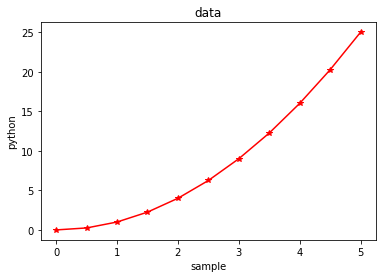

```python
#plotting a graph

pyp.plot(x,y,"red",marker = "*")
pyp.xlabel("sample")
pyp.ylabel("python")
pyp.title("data")
```

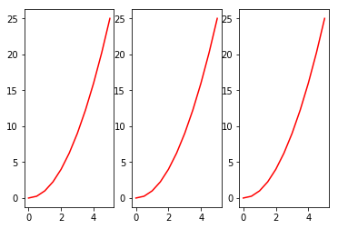

```python
#printing subplots(nrows,ncolumns,positions)
pyp.subplot(1,3,1)
pyp.plot(x,y,"r")
pyp.subplot(1,3,2)
pyp.plot(x,y,"r")
pyp.subplot(1,3,3)
pyp.plot(x,y,"r")
```

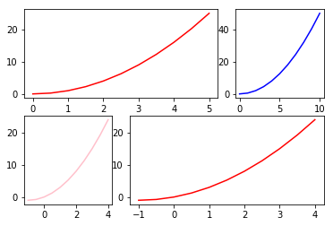

```python
#printing multiple sublots
pyp.subplot(2,3,(1,2))
pyp.plot(x,y,"r")
pyp.subplot(2,3,3)
pyp.plot(x*2,y*2,"b")
pyp.subplot(2,3,4)
pyp.plot(x-1,y-1,"pink")
pyp.subplot(2,3,(5,6))
pyp.plot(x-1,y-1,"r")
```

**Object Oriented Way:**

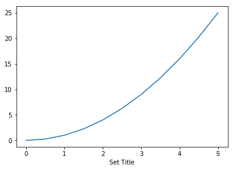

```python
#add axes(position from left,position from bottom,width,height)
fig  =  pyp.figure()
axes = fig.add_axes([0.1,0.1,0.8,0.8])
axes.plot(x,y)
axes.set_xlabel("X Label")
axes.set_xlabel("Y Label")
axes.set_xlabel("Set Title")
```

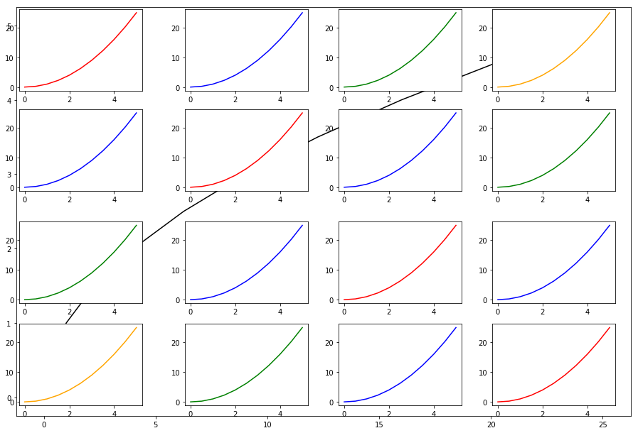

```python
#ax.plot(x,y,colour = " ",linewidth = 3(thickness of line),linestyle = "--",marker = "+",markersize = 10)
fig = pyp.figure()

axes1 = fig.add_axes([0,0,2,2])
axes1.plot(y,x,"black")
axes2 = fig.add_axes([0.01,1.59,0.40,0.40])
axes2.plot(x,y,"r")
axes3 = fig.add_axes([0.55,1.59,0.4,0.40])
axes3.plot(x,y,"B")
axes4 = fig.add_axes([0.01,1.1,0.4,0.4])
axes4.plot(x,y,"B")
axes5 = fig.add_axes([0.55,1.1,0.4,0.4])
axes5.plot(x,y,"R")
axes6 = fig.add_axes([0.01,0.55,0.4,0.4])
axes6.plot(x,y,"G")
axes7 = fig.add_axes([0.55,0.55,0.4,0.4])
axes7.plot(x,y,"B")
axes8 = fig.add_axes([0.01,0.05,0.4,0.4])
axes8.plot(x,y,"ORANGE")
axes9 = fig.add_axes([0.55,0.05,0.4,0.4])
axes9.plot(x,y,"G")
axes10 = fig.add_axes([1.05,1.59,0.40,0.40])
axes10.plot(x,y,"GREEN")
axes11 = fig.add_axes([1.55,1.59,0.4,0.40])
axes11.plot(x,y,"ORANGE")
axes12 = fig.add_axes([1.05,1.1,0.4,0.4])
axes12.plot(x,y,"B")
axes13 = fig.add_axes([1.55,1.1,0.4,0.4])
axes13.plot(x,y,"G")
axes14 = fig.add_axes([1.05,0.55,0.4,0.4])
axes14.plot(x,y,"R")
axes15 = fig.add_axes([1.55,0.55,0.4,0.4])
axes15.plot(x,y,"B")
axes16 = fig.add_axes([1.05,0.05,0.4,0.4])
axes16.plot(x,y,"B")
axes17= fig.add_axes([1.55,0.05,0.4,0.4])
axes17.plot(x,y,"R")
```

**Plotting With Various Parameters:**

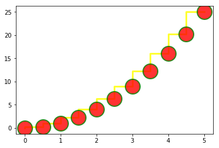

```python
#ax.plot(x,y,colour = " ",linewidth = 3(thickness of line),linestyle = "--",marker = "+",markersize = 10,alpha = (transparency),markeredgecolor = "",markeredgewidth = ,markerfacecolor ="")
pyp.plot(x,y, color="Yellow",linewidth = 3,alpha = 0.8,linestyle = "steps",marker ="o",markersize = 25,markerfacecolor = "red",markeredgewidth = 2 ,markeredgecolor = "Green")
```

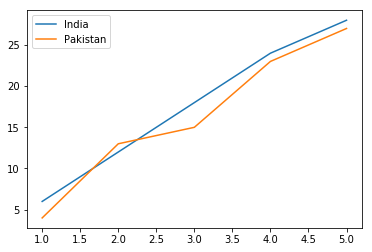

```python
#Plotting two different lines in  a graph
pyp.plot([1,2,3,4,5],[6,12,18,24,28], label = "India")
pyp.plot([1,2,3,4,5],[4,13,15,23,27], label = "Pakistan")
pyp.legend()
#representing score analysis of two team with line chart
```

# Plotting using SEABORN

## Seaborn

Seaborn is a Python data visualization library based on matplotlib. It provides a high-level interface for drawing attractive and informative statistical graphics. Here is some of the functionality that seaborn offers:

- A dataset-oriented API for examining relationships between multiple variables
- Specialized support for using categorical variables to show observations or aggregate statistics
- Options for visualizing univariate or bivariate distributions and for comparing them between subsets of data
- Automatic estimation and plotting of linear regression models for different kinds dependent variables
- Convenient views onto the overall structure of complex datasets
- High-level abstractions for structuring multi-plot grids that let you easily build complex visualizations
- Concise control over matplotlib figure styling with several built-in themes
- Tools for choosing color palettes that faithfully reveal patterns in your data

## Categorical DataPlots

1.factorplot

2.boxplot

3.violinplot

4.stripplot

5.swarmplot

```python
mob_data.head()
```

|  | PhoneId | Pixel Density | Screen Size | Weight | RAM | Processor_frequency | Screen to Body Ratio (calculated) | Height | Internal Memory | Capacity | Resolution | Rating | Brand | OS Name | Sim 1 | Sim 2 | SIM Slot | Processesor |
| --- | --- | --- | --- | --- | --- | --- | --- | --- | --- | --- | --- | --- | --- | --- | --- | --- | --- | --- |
| 0 | 0 | 403 | 6.26 | 182 | 4 | 1.8 | 80.68 | 157.9 | 64 | 4000 | 20 | 4.5 | Xiaomi | Android | 4G | 4G | Dual SIM, GSM+GSM, Dual VoLTE | Octa |
| 1 | 1 | 271 | 6.20 | 168 | 3 | 1.8 | 80.85 | 156.2 | 32 | 4230 | 8 | 4.5 | Realme | Android | 4G | 4G | Dual SIM, GSM+GSM, Dual VoLTE | Octa |
| 2 | 2 | 409 | 6.30 | 168 | 3 | 2.1 | 83.68 | 157.0 | 32 | 3500 | 25 | 4.4 | Realme | Android | 4G | 4G | Dual SIM, GSM+GSM, Dual VoLTE | Octa |
| 3 | 4 | 411 | 6.00 | 169 | 4 | 2.2 | 74.78 | 159.8 | 64 | 3300 | 24 | 4.3 | Samsung | Android | 4G | 4G | Dual SIM, GSM+GSM | Octa |
| 4 | 5 | 396 | 6.50 | 175 | 4 | 2.2 | 84.23 | 160.4 | 64 | 3750 | 16 | 4.4 | Honor | Android | 4G | 4G | Dual SIM, GSM+GSM, Dual VoLTE | Octa |

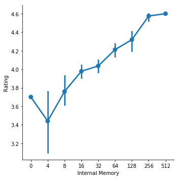

```python
#(x = "",y ="",data = dataset)
sb.factorplot(x='Internal Memory', y = 'Rating',  data = mob_data)
```

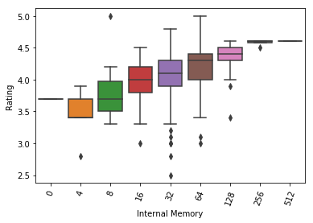

```python
sb.boxplot(x="Internal Memory",y="Rating",data=mob_data)
pyp.xticks(rotation = 70)#rotating x axis labels
```

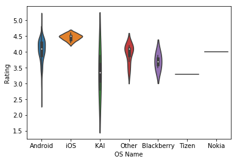

```python
sb.violinplot(x="OS Name",y = "Rating", data = mob_data)
```

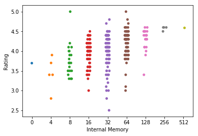

```python
sb.stripplot(x="Internal Memory",y="Rating",data=mob_data)
```

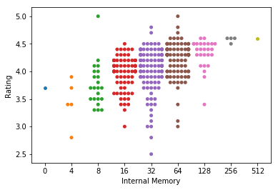

```python
sb.swarmplot(x="Internal Memory",y="Rating",data=mob_data)
```

Categorical scatter plot without **Jittering** along x axis

# Distribution plots

1.Distplot

2.Jointplot

3.pairplot

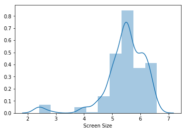

```python
#kde refers density estimation,bins refers size of tabs
sb.distplot(mob_data["Screen Size"],kde=True,bins=10)
```

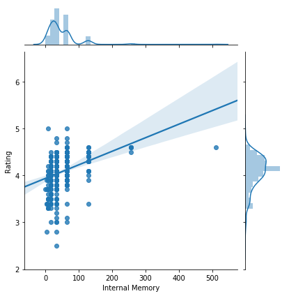

```python
sb.jointplot(x= "Internal Memory",y="Rating",data = mob_data,kind = "reg")
```

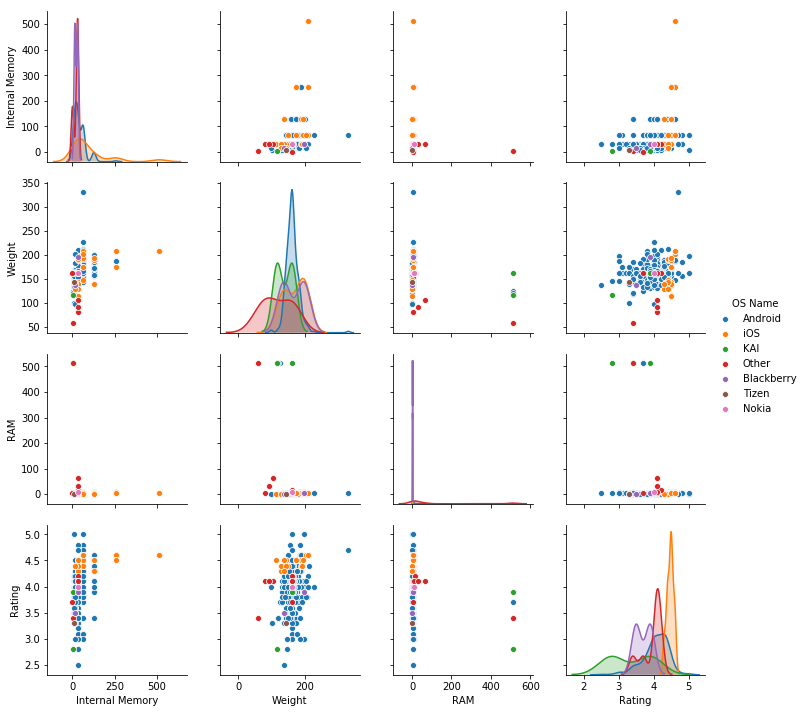

```python
#pairplotiing required columns with hue
sb.pairplot(mob_data,vars=["Internal Memory","Weight","RAM","Rating"],hue = "OS Name")
```

Correlating and Visualising data.

## Matrix Maps

1.HeatMaps

2.clusterMaps

```python
corr = mob_data.corr()
```

```python
corr
```

|  | PhoneId | Pixel Density | Screen Size | Weight | RAM | Processor_frequency | Screen to Body Ratio (calculated) | Height | Internal Memory | Capacity | Resolution | Rating |
| --- | --- | --- | --- | --- | --- | --- | --- | --- | --- | --- | --- | --- |
| PhoneId | 1.000000 | -0.086085 | -0.293952 | -0.091295 | -0.056188 | -0.327570 | -0.291145 | -0.258175 | -0.148973 | -0.193493 | -0.378437 | -0.372603 |
| Pixel Density | -0.086085 | 1.000000 | 0.484592 | 0.384774 | -0.209022 | 0.639060 | 0.480382 | 0.440141 | 0.428678 | 0.296012 | 0.282635 | 0.216119 |
| Screen Size | -0.293952 | 0.484592 | 1.000000 | 0.550287 | -0.405488 | 0.435525 | 0.930492 | 0.861143 | 0.433207 | 0.582681 | 0.472378 | 0.359243 |
| Weight | -0.091295 | 0.384774 | 0.550287 | 1.000000 | -0.249511 | 0.366023 | 0.438535 | 0.642595 | 0.389398 | 0.687891 | 0.231051 | 0.229059 |
| RAM | -0.056188 | -0.209022 | -0.405488 | -0.249511 | 1.000000 | -0.155368 | -0.328073 | -0.227798 | -0.098095 | -0.197554 | -0.074343 | -0.196753 |
| Processor_frequency | -0.327570 | 0.639060 | 0.435525 | 0.366023 | -0.155368 | 1.000000 | 0.403571 | 0.373361 | 0.578258 | 0.196266 | 0.401506 | 0.448580 |
| Screen to Body Ratio (calculated) | -0.291145 | 0.480382 | 0.930492 | 0.438535 | -0.328073 | 0.403571 | 1.000000 | 0.744119 | 0.417565 | 0.470404 | 0.449183 | 0.343126 |
| Height | -0.258175 | 0.440141 | 0.861143 | 0.642595 | -0.227798 | 0.373361 | 0.744119 | 1.000000 | 0.356375 | 0.635365 | 0.469851 | 0.266972 |
| Internal Memory | -0.148973 | 0.428678 | 0.433207 | 0.389398 | -0.098095 | 0.578258 | 0.417565 | 0.356375 | 1.000000 | 0.205356 | 0.390868 | 0.355757 |
| Capacity | -0.193493 | 0.296012 | 0.582681 | 0.687891 | -0.197554 | 0.196266 | 0.470404 | 0.635365 | 0.205356 | 1.000000 | 0.240943 | 0.210616 |
| Resolution | -0.378437 | 0.282635 | 0.472378 | 0.231051 | -0.074343 | 0.401506 | 0.449183 | 0.469851 | 0.390868 | 0.240943 | 1.000000 | 0.259884 |
| Rating | -0.372603 | 0.216119 | 0.359243 | 0.229059 | -0.196753 | 0.448580 | 0.343126 | 0.266972 | 0.355757 | 0.210616 | 0.259884 | 1.000000 |

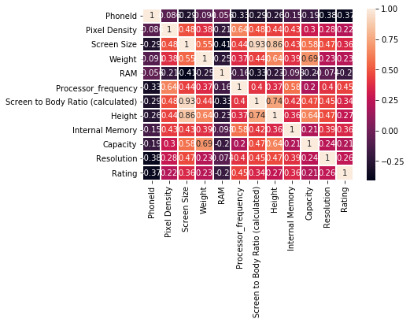

```python
#annot = values showing inside box,fmt = "formatting number",linewitdth = to sepearte and show,line colour = colour of seperation)
sb.heatmap(corr,annot = True,linewidth = 1,linecolor = "w")
```

```python
#pivot table(value = "must be numerical")
mob_data.pivot_table(values = "Weight",index = "RAM",columns = "Internal Memory")
```

| Internal Memory RAM | 0 | 4 | 8 | 16 | 32 | 64 | 128 | 256 | 512 |
| --- | --- | --- | --- | --- | --- | --- | --- | --- | --- |
| 1 | NaN | NaN | 144.105263 | 146.666667 | 129.000000 | NaN | NaN | NaN | NaN |
| 2 | NaN | NaN | NaN | 153.672727 | 150.000000 | 148.000000 | 138.0000 | NaN | NaN |
| 3 | 161.0 | NaN | 150.000000 | 157.076923 | 161.458333 | 187.000000 | 191.0000 | 174.0 | NaN |
| 4 | NaN | NaN | NaN | 161.000000 | 160.913043 | 166.681818 | 163.5000 | 208.0 | 208.0 |
| 6 | NaN | NaN | NaN | NaN | NaN | 183.555556 | 173.5625 | NaN | NaN |
| 8 | NaN | NaN | NaN | NaN | 161.000000 | 197.000000 | 186.8000 | 186.5 | NaN |
| 16 | NaN | NaN | NaN | NaN | 161.000000 | NaN | NaN | NaN | NaN |
| 32 | NaN | NaN | NaN | NaN | 91.000000 | NaN | NaN | NaN | NaN |
| 64 | NaN | NaN | NaN | NaN | 105.000000 | NaN | NaN | NaN | NaN |
| 512 | NaN | 116.0 | NaN | NaN | NaN | NaN | NaN | NaN | NaN |

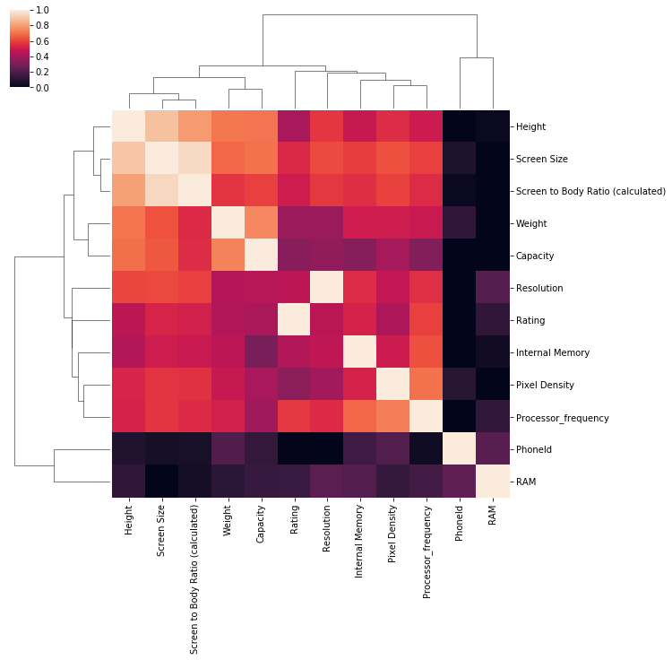

```python
sb.clustermap(corr,standard_scale=.5)
```

Pandas Inbuilt Graphs

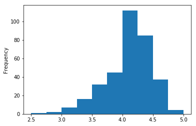

```python
mob_data["Rating"].plot.hist()
```

From this we can conclude many users opt rating in 4 - 4.5.

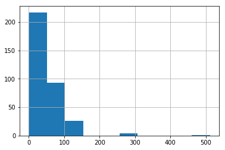

```python
mob_data["Internal Memory"].hist()
```

From this we can coclude many phones have memory in range 0 to 50

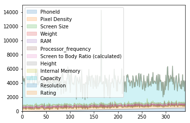

```python
#alpha represents transparency
mob_data.plot.area(alpha=0.2)
```

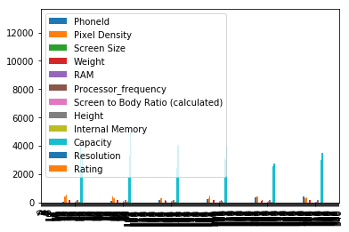

```python
mob_data.plot.bar()
```

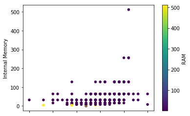

```python
mob_data.plot.scatter(x= "Rating",y="Internal Memory",c= "RAM",cmap = "viridis")
```

```python
df = pd.DataFrame(np.random.randn(1000,2),columns = list("ab"))
```

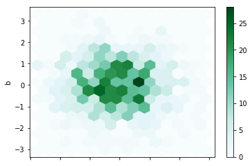

```python
df.plot.hexbin(x="a",y="b",gridsize=15)
```

From this we conclude most random value lie in same range..

```python
#using seed not to change random values
np.random.seed(5)
```

```python
#creating a random np array
x=np.arange(0.0,50,2)
```

```python
y = x**1.3+np.random.rand(*x.shape)*20
```

```python
s= np.random.rand(*x.shape)*800+500
```

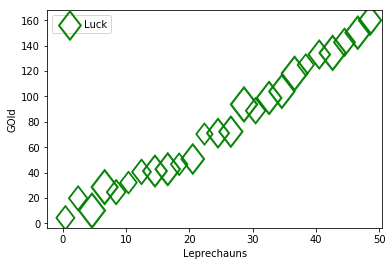

```python
pyp.scatter(x,y,s,c="g",alpha=0.9,marker = r'$\diamondsuit$',label="Luck")
pyp.xlabel("Leprechauns")
pyp.ylabel("GOld")
pyp.legend(loc="upper left")
```